# learning analysis, new subjects

Ben Smith

2022-12-19

We’ve noticed an accumbens signal that has a particularly pronounced CS-FS difference among late trials.

That led us to ask: is it correlated with reaction time; specifically,

1. is accumbens BOLD CS-FS contrast at tone+5 s (which reacts negatively) negatively related to longer reaction times in subsequent trials, and
2. is accumbens bold CS-FS contrast at tone+9 (which reacts positively) positively related to longer reaction times in subsequent trials?

We are really mostly interested in FS so at the trial level we’d do

1. is accumbens BOLD FS contrast at tone+5 s (which reacts positively) positively related to longer reaction times in subsequent trials, and
2. is accumbens bold FS contrast at tone+9 (which reacts negatively) negatively related to longer reaction times in subsequent trials?

# Prep

```r
library(tidyverse)
Sys.setenv(R_CONFIG_ACTIVE = Sys.info()["nodename"])
print(Sys.info()["nodename"])
```

```
##                        nodename
## "Benjamins-MacBook-Pro-2.local"
```

```r
dropbbox_dir <- config::get("dev_analysis_data_dir")
```

```r
time_points <- readr::read_csv(paste0(dropbbox_dir,"/SST_roi_by_time_point.csv"))
```

```
## ──────────────────────────────────────────────────────── Delimiter: "," chr
## (3): subid, go_no_go_condition_label, condition dbl (15): ...1, tr, offset,
## CueFollowing(CS>FS)striatal_cluster_combined, ha...
```

So how do we design this experiment; what are we correlating over, exactly? Some designs are:

1. Across subject, so:
1. apply the script I have created on late trials to get average measurements every 10 s–maybe the last half or third of the task, not just the last few, but do this at a per subject level
2. take the MAXIMUM accumbens activity at the 1-9 s range across trials for each subject (to get the peak), and the MINIMUM accumbens activity at the 4-12 s range (to get the trough)
3. correlate across subject average reaction times, or post-pre change in reaction times
2. Within subject, so:
1. get peak and trough accumbens signal for each FS trial in the last third of the task. Perhaps use the difference between the peak and trough as your measure. Though we’re really now kind of getting a crude HRF…the advantage of this measure is we aren’t bound to a particular shape of it, which is probably useful.
2. get (i) reaction time and (ii) post-pre difference for subsequent go trial
3. correlate the difference of peak and trough gathered in (a) with the two measures in (b). Summarize in two ways: i. get average correlations within-subject, then average across subjects as a crude multi-level model to test across subject ii. apply a true multi-level model

We’ll want to re-use existing pre-post data.

So–this will yield quite different data to the data we used previously!

```r
roi_cols <- colnames(time_points)[grepl("harvardoxford",colnames(time_points))]
time_points$tr_roi_mean <- rowMeans(time_points[,roi_cols])
time_points<-
  time_points %>% group_by(subid,wave) %>%
  mutate(run_mean_across_rois = mean(tr_roi_mean, na.rm = TRUE))

#now mean-center the ROIs
time_points_c<-time_points
for (roi_col in roi_cols){
  time_points_c[,roi_col]<-time_points_c[,roi_col]-time_points_c$run_mean_across_rois
}

#roi_cols <- colnames(time_points_c)[grepl("harvardoxford",colnames(time_points_c))]
#roi_cols_all <- colnames(time_points_c)#[grepl("((?<=harvardoxford-.{0,3}cortical_prob_)(.*))|(CueFollowing\\(CS\\>FS\\).*)",colnames(time_points_c),perl=TRUE)]
roi_detect_pattern<-"((?<=harvardoxford-.{0,3}cortical_prob_)(.*))|(CueFollowing\\(CS\\>FS\\).*)"

roi_cols_vec <- colnames(time_points_c) %>% stringr::str_detect(pattern = roi_detect_pattern)
new_roi_cols <- colnames(time_points_c) %>% stringr::str_extract_all(pattern = roi_detect_pattern) %>% unlist
unique(new_roi_cols)
```

```
## [1] "CueFollowing(CS>FS)striatal_cluster_combined"
## [2] "Frontal Orbital Cortex"
## [3] "Cingulate Gyrus, anterior division"
## [4] "Left Caudate"
## [5] "Right Accumbens"
## [6] "Right Putamen"
## [7] "Left Putamen"
## [8] "Right Caudate"
## [9] "Left Accumbens"
```

```r
colnames(time_points_c)[roi_cols_vec] <- new_roi_cols
```

We need to group by subject, wave, and trial, select just the FailedStop trials, and just the high trial numbers, then get the min and max accumbens activity. We could even do a long transform across the ROIs, then also group by ROI and get the min and max for ROIs

So let’s first long transform the ROIs

```r
tpc_long<-time_points_c %>% pivot_longer(cols=all_of(new_roi_cols),names_to="ROI",values_to="value")
```

Now do the grouping and summarizing.

```r
trial_summary_data <- tpc_long %>%
  #filter(condition=="FailedStop") %>%
  group_by(subid,wave,trial_n,ROI, condition) %>%
  summarise(
    peak=max(value[offset>=1.0 & offset <=5.0],na.rm = TRUE),
    trough = min(value[offset>=0.0 & offset <=5.0],na.rm = TRUE),
    peak_time = offset[offset>=1.0 & offset <=5.0][value[offset>=1.0 & offset <=5.0]==max(value[offset>=1.0 & offset <=5.0],na.rm = TRUE)],
    trough_time = offset[offset>=0.0 & offset <=5.0][value[offset>=0.0 & offset <=5.0]==min(value[offset>=0.0 & offset <=5.0],na.rm = TRUE)]
  )
```

```
## 'condition'. You can override using the `.groups` argument.
```

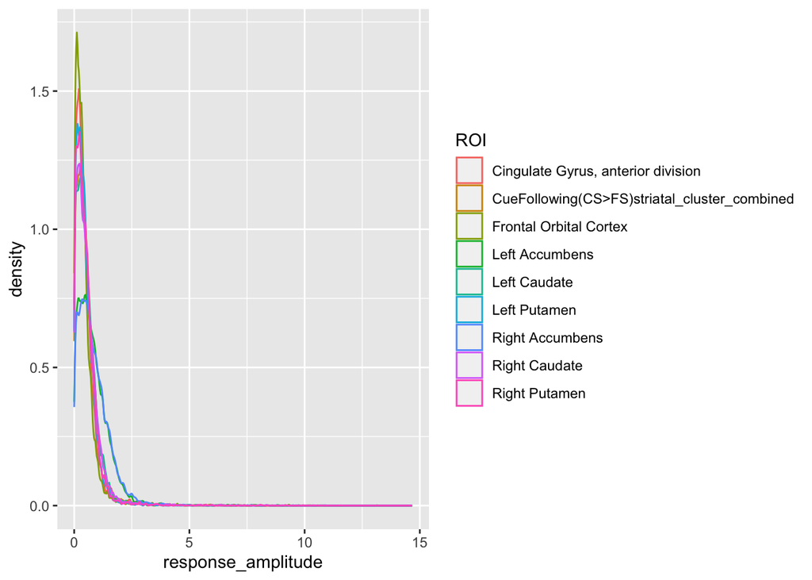

```r
trial_summary_data$response_amplitude <-trial_summary_data$peak-trial_summary_data$trough

ggplot(trial_summary_data %>% filter(condition=="FailedStop"),aes(response_amplitude,group=ROI,color=ROI))+geom_density(adjust=0.5)
```

OK. So now, let’s try to merge in that with post-pre RTs. Where do we get those from?

## get the SST Post-pre data

```r
source(paste0(config::get("ben_dev_data_analysis"),"SST_processing.R"))

dropbox_file_dir = config::get("dev_analysis_data_dir")
sst_all_data_filepath <- paste0(dropbox_file_dir,"sst_behavioral_data_all.csv")

sst_all_data_raw <- readr::read_csv(sst_all_data_filepath)
sst_all_data<-clean_sst_data(sst_all_data_raw)
sst_all_data <- get_expected_tone_time(sst_all_data)

sst_all_data<-calculate_response_latency(sst_all_data)
sst_all_data<-calculate_rpe(sst_all_data)


# sst_all_data %>% select(
#   subid, waveid, runid, reaction_time_clean, SSD_recorded,condition, last_tone_delay, trials_since_last_SSD,last_correct_go)# %>%
#   #View()
```

```r
readr::write_csv(sst_all_data,file=paste0(dropbox_file_dir,"sst_behavioral_data_all_with_analysis.csv"))
```

```r
post_pre_rt_data <- sst_all_data%>%
  filter(condition!="Cue") #%>%
  #select(trial_n,reaction_time,subid,waveid,runid,condition,post_pre_rt_change)
```

## Prepare neural data

```r
trial_summary_data$ROI_delateralized <-  trial_summary_data$ROI %>% str_replace_all("(Left|Right)\\s","")


trial_summary_data_delat <- trial_summary_data %>%
  #filter(ROI %in% c("Left Accumbens","Right Accumbens")) %>%
  group_by(subid,wave,trial_n, ROI_delateralized,condition) %>%
  summarize(peak=mean(peak),
            trough=mean(trough),
            peak_time=mean(peak_time),
            trough_time=mean(trough_time),
            response_amplitude=mean(response_amplitude))
```

```
## 'ROI_delateralized'. You can override using the `.groups` argument.
```

## Merge the datasets

```r
trial_summary_data_delat_pp <- merge(trial_summary_data_delat,post_pre_rt_data,by.x = c("subid","wave","trial_n","condition"),by.y=c("subid","waveid","trial_n","condition"),all.x = TRUE)

trial_summary_data_delat_pp$trial_n_c<-128-trial_summary_data_delat_pp$trial_n

FS_summary_data_accumbens <- trial_summary_data_delat_pp %>%
  filter(ROI_delateralized=="Accumbens" & condition=="FailedStop") %>% select(-ROI_delateralized)



FS_neural_behav_data_not_na<-FS_summary_data_accumbens[
  rowSums(is.na(FS_summary_data_accumbens[,c("response_amplitude","post_pre_rt_change")]))==0 & #no NA values in correlation and
    is.finite(FS_summary_data_accumbens$response_amplitude) & is.finite(FS_summary_data_accumbens$post_pre_rt_change) #no infinite values
    ,]
```

# Single-level tests

```r
FS_by_subj_raw <- FS_neural_behav_data_not_na %>% group_by(subid) %>%
  mutate(trial_count=n())
FS_by_subj <- FS_by_subj_raw %>% filter(trial_count >2) %>%
  summarize(peak_cor_est = cor.test(peak,post_pre_rt_change)$estimate,
            amplitude_cor_est = cor.test(response_amplitude,post_pre_rt_change)$estimate,
            mean_post_pre_rt_change=mean(post_pre_rt_change),
            mean_post_current_rt_change=mean(post_current_rt_change),
            mean_peak=mean(peak),
            mean_trough=mean(trough),
            mean_amplitude=mean(response_amplitude),
            trial_count=n()
            )

t.test(FS_by_subj$peak_cor_est)
```

```
##
##  One Sample t-test
##
## data:  FS_by_subj$peak_cor_est
## t = 0.71759, df = 243, p-value = 0.4737
## alternative hypothesis: true mean is not equal to 0
## 95 percent confidence interval:
##  -0.02230136  0.04786170
## sample estimates:
##  mean of x
## 0.01278017
```

```r
t.test(FS_by_subj$amplitude_cor_est)
```

```
##
##  One Sample t-test
##
## data:  FS_by_subj$amplitude_cor_est
## t = -0.9853, df = 243, p-value = 0.3255
## alternative hypothesis: true mean is not equal to 0
## 95 percent confidence interval:
##  -0.04812830  0.01603389
## sample estimates:
##  mean of x
## -0.0160472
```

Would strengthen the data

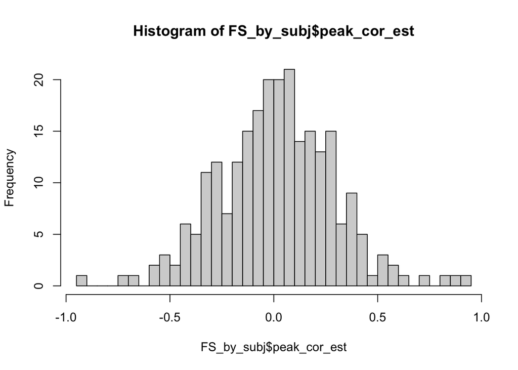

```r
hist(FS_by_subj$peak_cor_est,breaks=40)
```

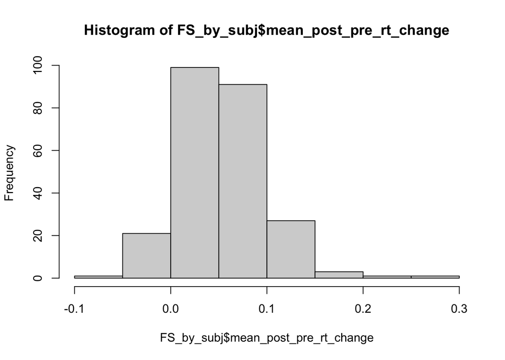

```r
hist(FS_by_subj$mean_post_pre_rt_change)
```

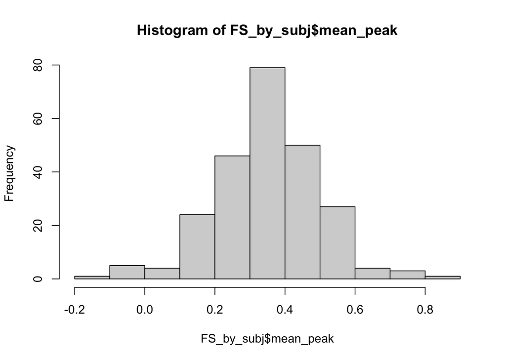

```r
hist(FS_by_subj$mean_peak)
```

```r
cor.test(FS_by_subj$mean_post_pre_rt_change,FS_by_subj$mean_trough)
```

```
##
##  Pearson's product-moment correlation
##
## data:  FS_by_subj$mean_post_pre_rt_change and FS_by_subj$mean_trough
## t = -2.8532, df = 242, p-value = 0.004703
## alternative hypothesis: true correlation is not equal to 0
## 95 percent confidence interval:
##  -0.29920774 -0.05608554
## sample estimates:
##        cor
## -0.1804007
```

```r
cor.test(FS_by_subj$mean_post_pre_rt_change,FS_by_subj$mean_peak)
```

```
##
##  Pearson's product-moment correlation
##
## data:  FS_by_subj$mean_post_pre_rt_change and FS_by_subj$mean_peak
## t = 0.69143, df = 242, p-value = 0.49
## alternative hypothesis: true correlation is not equal to 0
## 95 percent confidence interval:
##  -0.08163786  0.16904635
## sample estimates:
##       cor
## 0.0444032
```

```r
cor.test(FS_by_subj$mean_post_pre_rt_change,FS_by_subj$mean_amplitude)
```

```
##
##  Pearson's product-moment correlation
##
## data:  FS_by_subj$mean_post_pre_rt_change and FS_by_subj$mean_amplitude
## t = 3.5222, df = 242, p-value = 0.0005114
## alternative hypothesis: true correlation is not equal to 0
## 95 percent confidence interval:
##  0.09795789 0.33706515
## sample estimates:
##       cor
## 0.2208271
```

```r
cor.test(FS_by_subj$mean_post_pre_rt_change,FS_by_subj$mean_peak,method="spearman")
```

```
##
##  Spearman's rank correlation rho
##
## data:  FS_by_subj$mean_post_pre_rt_change and FS_by_subj$mean_peak
## S = 2246478, p-value = 0.2616
## alternative hypothesis: true rho is not equal to 0
## sample estimates:
##        rho
## 0.07212123
```

Not significant within subjects, either. OK. We can do a multi-level model but I don’t think we’re quite capable of pulling this out.

If you take away the accumbens selection, you do get some significant results, but these are taking false precision…

## Between subjects

```r
trial_neural_behav_data_not_na<-trial_summary_data_delat_pp[
  rowSums(is.na(trial_summary_data_delat_pp[,c("response_amplitude","post_pre_rt_change")]))==0 & #no NA values in correlation and
    is.finite(trial_summary_data_delat_pp$response_amplitude) & is.finite(trial_summary_data_delat_pp$post_pre_rt_change) #no infinite values
    ,]

trial_neural_behav_data_not_na$trial_n_c<-128-trial_neural_behav_data_not_na$trial_n
trial_neural_behav_data_not_na$trial_n_n<-scale(trial_neural_behav_data_not_na$trial_n_c)


FS_neural_behav_data_not_na<-trial_neural_behav_data_not_na[trial_neural_behav_data_not_na$condition=="FailedStop",]
```

```r
full_run_data <- sst_all_data %>% group_by(subid,waveid,runid) %>%
  summarize(mean_SSD_all_stop_trials=mean(SSD_recorded[SSD_recorded!=0]))
FS_by_subj_raw <- FS_neural_behav_data_not_na %>% group_by(ROI_delateralized, subid) %>%
  mutate(trial_count=n())
FS_by_subj <- FS_by_subj_raw %>% group_by(ROI_delateralized, subid,trial_count) %>% filter(trial_count >2) %>%
  summarize(peak_cor_est = cor.test(peak,post_pre_rt_change)$estimate,
            trough_cor_est = cor.test(trough,post_pre_rt_change)$estimate,
            amplitude_cor_est = cor.test(response_amplitude,post_pre_rt_change)$estimate,
            mean_post_pre_rt_change=mean(post_pre_rt_change),
            mean_post_current_rt_change=mean(post_current_rt_change),
            mean_post_rt=mean(next_reaction_time),
            mean_peak=mean(peak),
            mean_trough=mean(trough),
            mean_amplitude=mean(response_amplitude),
            mean_peak_offset=mean(peak_time),
            mean_trough_offset=mean(trough_time),

            )
FS_by_subj<-merge(FS_by_subj,
                  full_run_data %>% filter(runid==1 & waveid==1),
                  by='subid',how='left'
                  )

FS_neural_behav_data_not_na <- merge(
  FS_neural_behav_data_not_na %>% filter(runid==1),
  full_run_data %>% filter(runid==1 & waveid==1),
                  by=c('subid','runid'),how='left'
                  )
```

## Per subject:

```r
roi_within_subj_list<-list()

for (roi_i in unique(FS_by_subj$ROI_delateralized)){
  # cat("\n")
  # cat(roi_i)
  # cat("\n")
  peak<-t.test(FS_by_subj %>% filter(ROI_delateralized==roi_i) %>% .$peak_cor_est)
  trough<-t.test(FS_by_subj %>% filter(ROI_delateralized==roi_i) %>% .$trough_cor_est)
  amplitude<-t.test(FS_by_subj %>% filter(ROI_delateralized==roi_i) %>% .$amplitude_cor_est)
  # print(peak)
  # print(trough)
  # print(amplitude)

  roi_within_subj_row<-data.frame("roi"=roi_i,"measure"="peak","t"=peak[[1]],"estimate"=peak$estimate, "pvalue"=peak$p.value)
  roi_within_subj_list<-append(roi_within_subj_list,list(roi_within_subj_row))
  roi_within_subj_row<-data.frame("roi"=roi_i,"measure"="trough","t"=trough[[1]],"estimate"=trough$estimate, "pvalue"=trough$p.value)
  roi_within_subj_list<-append(roi_within_subj_list,list(roi_within_subj_row))
  roi_within_subj_row<-data.frame("roi"=roi_i,"measure"="amplitude","t"=amplitude[[1]],"estimate"=amplitude$estimate, "pvalue"=amplitude$p.value)
  roi_within_subj_list<-append(roi_within_subj_list,list(roi_within_subj_row))
  # cat("---\n")
}
print("example:")
```

```
## [1] "example:"
```

```r
cat(roi_i)
```

```
## Putamen
```

```r
cat("\n")
```

```r
print(peak)
```

```
##
##  One Sample t-test
##
## data:  FS_by_subj %>% filter(ROI_delateralized == roi_i) %>% .$peak_cor_est
## t = 2.2729, df = 243, p-value = 0.0239
## alternative hypothesis: true mean is not equal to 0
## 95 percent confidence interval:
##  0.004951738 0.069302212
## sample estimates:
##  mean of x
## 0.03712698
```

```r
  print(trough)
```

```
##
##  One Sample t-test
##
## data:  FS_by_subj %>% filter(ROI_delateralized == roi_i) %>% .$trough_cor_est
## t = 0.85987, df = 243, p-value = 0.3907
## alternative hypothesis: true mean is not equal to 0
## 95 percent confidence interval:
##  -0.01809450  0.04613102
## sample estimates:
##  mean of x
## 0.01401826
```

```r
  print(amplitude)
```

```
##
##  One Sample t-test
##
## data:  FS_by_subj %>% filter(ROI_delateralized == roi_i) %>% .$amplitude_cor_est
## t = 1.5582, df = 243, p-value = 0.1205
## alternative hypothesis: true mean is not equal to 0
## 95 percent confidence interval:
##  -0.007187248  0.061601754
## sample estimates:
##  mean of x
## 0.02720725
```

```r
  cat("---\n")
roi_within_subj_df <- do.call(rbind,roi_within_subj_list)

library(stats)
roi_within_subj_df$pvalue_fdr_adjust<-p.adjust(roi_within_subj_df$pvalue,method="fdr")
roi_within_subj_df <- roi_within_subj_df %>% mutate(signif=ifelse(pvalue_fdr_adjust<0.05,"*",""))

print("summary:")
```

```
## [1] "summary:"
```

```r
print(roi_within_subj_df)
```

```
##                                              roi   measure          t
## t                                      Accumbens      peak  0.7175870
## t1                                     Accumbens    trough  1.7435623
## t2                                     Accumbens amplitude -0.9852958
## t3                                       Caudate      peak  1.1818976
## t4                                       Caudate    trough  0.1559778
## t5                                       Caudate amplitude  0.4175716
## t6            Cingulate Gyrus, anterior division      peak  2.5471684
## t7            Cingulate Gyrus, anterior division    trough  1.0225389
## t8            Cingulate Gyrus, anterior division amplitude  0.9693913
## t9  CueFollowing(CS>FS)striatal_cluster_combined      peak  3.8821018
## t10 CueFollowing(CS>FS)striatal_cluster_combined    trough  2.8097894
## t11 CueFollowing(CS>FS)striatal_cluster_combined amplitude  0.8952534
## t12                       Frontal Orbital Cortex      peak  3.1105770
## t13                       Frontal Orbital Cortex    trough  2.2055076
## t14                       Frontal Orbital Cortex amplitude  0.5926193
## t15                                      Putamen      peak  2.2729208
## t16                                      Putamen    trough  0.8598705
## t17                                      Putamen amplitude  1.5581604
##         estimate       pvalue pvalue_fdr_adjust signif
## t    0.012780169 0.4737012031       0.568441444
## t1   0.028861025 0.0825001258       0.212143181
## t2  -0.016047205 0.3254587920       0.499970748
## t3   0.019758676 0.2384016263       0.476803253
## t4   0.002632091 0.8761800083       0.876180008
## t5   0.007284722 0.6766290791       0.716430790
## t6   0.044224489 0.0114775973       0.051649188
## t7   0.016971776 0.3075427728       0.499970748
## t8   0.015896840 0.3333138323       0.499970748
## t9   0.068110285 0.0001334844       0.002402719      *
## t10  0.048178725 0.0053610019       0.032166011      *
## t11  0.015229562 0.3715375473       0.502338771
## t12  0.051249970 0.0020902066       0.018811859      *
## t13  0.037000840 0.0283552825       0.085065847
## t14  0.009787747 0.5539870503       0.623235432
## t15  0.037126975 0.0239047556       0.085065847
## t16  0.014018262 0.3907079327       0.502338771
## t17  0.027207253 0.1204966260       0.271117408
```

Look

## across subjects

```r
roi_inddiv_list<-list()
for (roi_i in unique(FS_by_subj$ROI_delateralized)){
  cat("\n")
  cat(roi_i)
  cat("\n")
  FS_by_subj_i <- FS_by_subj %>% filter(ROI_delateralized==roi_i)

  peak<-cor.test(FS_by_subj_i$mean_post_pre_rt_change,FS_by_subj_i$mean_peak)
  trough<-cor.test(FS_by_subj_i$mean_post_pre_rt_change,FS_by_subj_i$mean_trough)
  amplitude<-cor.test(FS_by_subj_i$mean_post_pre_rt_change,FS_by_subj_i$mean_amplitude)
  #roi_inddiv_row<-data.frame("roi"=character(0),"measure"=character(0),"value"=numeric(0))
  roi_inddiv_row<-data.frame("roi"=roi_i,"measure"="peak","value"=peak[[1]],"estimate"=peak$estimate,"pvalue"=peak$p.value)
  roi_inddiv_list<-append(roi_inddiv_list,list(roi_inddiv_row))
  roi_inddiv_row<-data.frame("roi"=roi_i,"measure"="trough","value"=trough[[1]],"estimate"=trough$estimate,"pvalue"=trough$p.value)
  roi_inddiv_list<-append(roi_inddiv_list,list(roi_inddiv_row))
  roi_inddiv_row<-data.frame("roi"=roi_i,"measure"="amplitude","value"=amplitude[[1]],"estimate"=amplitude$estimate,"pvalue"=amplitude$p.value)
  roi_inddiv_list<-append(roi_inddiv_list,list(roi_inddiv_row))
  # print(peak)
  # print(trough)
  # print(amplitude)
  # cat("---\n")
}
```

```
##
## Accumbens
##
## Caudate
##
## Cingulate Gyrus, anterior division
##
## CueFollowing(CS>FS)striatal_cluster_combined
##
## Frontal Orbital Cortex
##
## Putamen
```

```r
print("example of full analyses for last ROI")
```

```
## [1] "example of full analyses for last ROI"
```

```r
cat(roi_i)
```

```
## Putamen
```

```r
  cat("\n")
```

```r
print(peak)
```

```
##
##  Pearson's product-moment correlation
##
## data:  FS_by_subj_i$mean_post_pre_rt_change and FS_by_subj_i$mean_peak
## t = 0.89091, df = 242, p-value = 0.3739
## alternative hypothesis: true correlation is not equal to 0
## 95 percent confidence interval:
##  -0.06890472  0.18145873
## sample estimates:
##        cor
## 0.05717587
```

```r
print(trough)
```

```
##
##  Pearson's product-moment correlation
##
## data:  FS_by_subj_i$mean_post_pre_rt_change and FS_by_subj_i$mean_trough
## t = -2.6397, df = 242, p-value = 0.008837
## alternative hypothesis: true correlation is not equal to 0
## 95 percent confidence interval:
##  -0.28685531 -0.04260565
## sample estimates:
##        cor
## -0.1672963
```

```r
print(amplitude)
```

```
##
##  Pearson's product-moment correlation
##
## data:  FS_by_subj_i$mean_post_pre_rt_change and FS_by_subj_i$mean_amplitude
## t = 3.4244, df = 242, p-value = 0.0007235
## alternative hypothesis: true correlation is not equal to 0
## 95 percent confidence interval:
##  0.09187885 0.33161657
## sample estimates:
##      cor
## 0.214984
```

```r
cat("---\n")
print("summary")
```

```
## [1] "summary"
```

```r
roi_inddiv_df <- do.call(rbind,roi_inddiv_list)

library(stats)
roi_inddiv_df$pvalue_fdr_adjust<-p.adjust(roi_inddiv_df$pvalue,method="fdr")
roi_inddiv_df <- roi_inddiv_df %>% mutate(signif=ifelse(pvalue_fdr_adjust<0.05,"*",""))

print(roi_inddiv_df)
```

```
##                                              roi   measure      value
## t                                      Accumbens      peak  0.6914337
## t1                                     Accumbens    trough -2.8531879
## t2                                     Accumbens amplitude  3.5222161
## t3                                       Caudate      peak  0.9376675
## t4                                       Caudate    trough -2.9610703
## t5                                       Caudate amplitude  3.6452901
## t6            Cingulate Gyrus, anterior division      peak -0.4466619
## t7            Cingulate Gyrus, anterior division    trough -3.2630468
## t8            Cingulate Gyrus, anterior division amplitude  3.3729035
## t9  CueFollowing(CS>FS)striatal_cluster_combined      peak  0.6882845
## t10 CueFollowing(CS>FS)striatal_cluster_combined    trough -2.6976480
## t11 CueFollowing(CS>FS)striatal_cluster_combined amplitude  3.1554364
## t12                       Frontal Orbital Cortex      peak  0.7263416
## t13                       Frontal Orbital Cortex    trough -2.4829761
## t14                       Frontal Orbital Cortex amplitude  3.2354609
## t15                                      Putamen      peak  0.8909052
## t16                                      Putamen    trough -2.6397226
## t17                                      Putamen amplitude  3.4244386
##        estimate       pvalue pvalue_fdr_adjust signif
## t    0.04440320 0.4899557881       0.520870110
## t1  -0.18040070 0.0047029310       0.009405862      *
## t2   0.22082707 0.0005114052       0.003896683      *
## t3   0.06016635 0.3493501589       0.480683437
## t4  -0.18698756 0.0033706645       0.007583995      *
## t5   0.22814806 0.0003269075       0.003896683      *
## t6  -0.02870068 0.6555186722       0.655518672
## t7  -0.20528907 0.0012612019       0.004151891      *
## t8   0.21189503 0.0008659296       0.003896683      *
## t9   0.04420136 0.4919328813       0.520870110
## t10 -0.17086138 0.0074744130       0.013453943      *
## t11  0.19879086 0.0018056313       0.004643052      *
## t12  0.04664020 0.4683312987       0.520870110
## t13 -0.15761666 0.0137076600       0.020561490      *
## t14  0.20362580 0.0013839636       0.004151891      *
## t15  0.05717587 0.3738648953       0.480683437
## t16 -0.16729633 0.0088366095       0.014459906      *
## t17  0.21498404 0.0007234677       0.003896683      *
```

# Basic Striatal cluster mixed effects models

The preliminary analysis suggests this should be significant both within and across individuals. Let’s see!

First let’s see if we should use the trial regressor.

```r
#FS_neural_behav_data_not_na$trial_n_c<-128-FS_neural_behav_data_not_na$trial_n

library(lme4)
FS_neural_behav_p <- FS_neural_behav_data_not_na %>% filter(ROI_delateralized=="CueFollowing(CS>FS)striatal_cluster_combined")

model_full_effects <- lme4::lmer(
   peak ~ trial_n_c +I(trial_n_c^2) + post_pre_rt_change + (1+ post_pre_rt_change | subid),
  FS_neural_behav_p
  )
summary(model_full_effects)
```

```
## Linear mixed model fit by REML ['lmerMod']
## Formula: peak ~ trial_n_c + I(trial_n_c^2) + post_pre_rt_change + (1 +
##     post_pre_rt_change | subid)
##    Data: FS_neural_behav_p
##
## REML criterion at convergence: 6318.7
##
## Scaled residuals:
##     Min      1Q  Median      3Q     Max
## -5.5519 -0.6401  0.0082  0.6232  3.9851
##
## Random effects:
##  Groups   Name               Variance Std.Dev. Corr
##  subid    (Intercept)        0.004451 0.06672
##           post_pre_rt_change 0.025302 0.15907  -0.21
##  Residual                    0.208155 0.45624
## Number of obs: 4867, groups:  subid, 244
##
## Fixed effects:
##                      Estimate Std. Error t value
## (Intercept)         2.564e-01  1.191e-02  21.524
## trial_n_c           1.988e-04  8.389e-05   2.370
## I(trial_n_c^2)     -5.242e-07  1.287e-06  -0.407
## post_pre_rt_change  2.163e-01  4.471e-02   4.837
##
## Correlation of Fixed Effects:
##             (Intr) trl_n_ I(__^2
## trial_n_c   -0.028
## I(trl_n_^2) -0.707 -0.130
## pst_pr_rt_c -0.221  0.086  0.023
## fit warnings:
## Some predictor variables are on very different scales: consider rescaling
```

```r
model_full_effects <- lme4::lmer(
   peak ~ trial_n_c +post_pre_rt_change + (1+ post_pre_rt_change | subid),
  FS_neural_behav_p
  )
summary(model_full_effects)
```

```
## Linear mixed model fit by REML ['lmerMod']
## Formula: peak ~ trial_n_c + post_pre_rt_change + (1 + post_pre_rt_change |
##     subid)
##    Data: FS_neural_behav_p
##
## REML criterion at convergence: 6293.6
##
## Scaled residuals:
##     Min      1Q  Median      3Q     Max
## -5.5566 -0.6398  0.0100  0.6230  3.9772
##
## Random effects:
##  Groups   Name               Variance Std.Dev. Corr
##  subid    (Intercept)        0.004431 0.06657
##           post_pre_rt_change 0.024795 0.15747  -0.20
##  Residual                    0.208141 0.45622
## Number of obs: 4867, groups:  subid, 244
##
## Fixed effects:
##                     Estimate Std. Error t value
## (Intercept)        2.529e-01  8.417e-03  30.050
## trial_n_c          1.944e-04  8.318e-05   2.338
## post_pre_rt_change 2.167e-01  4.466e-02   4.852
##
## Correlation of Fixed Effects:
##             (Intr) trl_n_
## trial_n_c   -0.171
## pst_pr_rt_c -0.289  0.090
```

here, we clearly need to include the trial, but no evidence for including the quadratic.

```r
model_full_effects <- lme4::lmer(
   peak ~ trial_n_c +post_pre_rt_change + (1+ post_pre_rt_change | subid),
  FS_neural_behav_p
  )
summary(model_full_effects)
```

```
## Linear mixed model fit by REML ['lmerMod']
## Formula: peak ~ trial_n_c + post_pre_rt_change + (1 + post_pre_rt_change |
##     subid)
##    Data: FS_neural_behav_p
##
## REML criterion at convergence: 6293.6
##
## Scaled residuals:
##     Min      1Q  Median      3Q     Max
## -5.5566 -0.6398  0.0100  0.6230  3.9772
##
## Random effects:
##  Groups   Name               Variance Std.Dev. Corr
##  subid    (Intercept)        0.004431 0.06657
##           post_pre_rt_change 0.024795 0.15747  -0.20
##  Residual                    0.208141 0.45622
## Number of obs: 4867, groups:  subid, 244
##
## Fixed effects:
##                     Estimate Std. Error t value
## (Intercept)        2.529e-01  8.417e-03  30.050
## trial_n_c          1.944e-04  8.318e-05   2.338
## post_pre_rt_change 2.167e-01  4.466e-02   4.852
##
## Correlation of Fixed Effects:
##             (Intr) trl_n_
## trial_n_c   -0.171
## pst_pr_rt_c -0.289  0.090
```

```r
model_fixed_effects <- lme4::lmer(
   peak ~ trial_n_c +post_pre_rt_change + (1 | subid),
  FS_neural_behav_p
  )
summary(model_fixed_effects)
```

```
## Linear mixed model fit by REML ['lmerMod']
## Formula: peak ~ trial_n_c + post_pre_rt_change + (1 | subid)
##    Data: FS_neural_behav_p
##
## REML criterion at convergence: 6294
##
## Scaled residuals:
##     Min      1Q  Median      3Q     Max
## -5.5477 -0.6421  0.0090  0.6236  4.0316
##
## Random effects:
##  Groups   Name        Variance Std.Dev.
##  subid    (Intercept) 0.004339 0.06587
##  Residual             0.208679 0.45681
## Number of obs: 4867, groups:  subid, 244
##
## Fixed effects:
##                     Estimate Std. Error t value
## (Intercept)        2.529e-01  8.384e-03  30.169
## trial_n_c          1.957e-04  8.318e-05   2.353
## post_pre_rt_change 2.168e-01  4.318e-02   5.021
##
## Correlation of Fixed Effects:
##             (Intr) trl_n_
## trial_n_c   -0.171
## pst_pr_rt_c -0.270  0.093
```

```r
anova(model_fixed_effects,model_full_effects)
```

```
## refitting model(s) with ML (instead of REML)
```

```
## Data: FS_neural_behav_p
## Models:
## model_fixed_effects: peak ~ trial_n_c + post_pre_rt_change + (1 | subid)
## model_full_effects: peak ~ trial_n_c + post_pre_rt_change + (1 + post_pre_rt_change | subid)
##                     npar    AIC    BIC  logLik deviance Chisq Df Pr(>Chisq)
## model_fixed_effects    5 6274.8 6307.2 -3132.4   6264.8
## model_full_effects     7 6278.4 6323.8 -3132.2   6264.4 0.386  2     0.8245
```

```r
model_random_only <- lme4::lmer(
   peak ~ trial_n_c +(1+ post_pre_rt_change | subid),
  FS_neural_behav_p
  )
summary(model_random_only)
```

```
## Linear mixed model fit by REML ['lmerMod']
## Formula: peak ~ trial_n_c + (1 + post_pre_rt_change | subid)
##    Data: FS_neural_behav_p
##
## REML criterion at convergence: 6311.3
##
## Scaled residuals:
##     Min      1Q  Median      3Q     Max
## -5.5608 -0.6305  0.0051  0.6163  3.7604
##
## Random effects:
##  Groups   Name               Variance Std.Dev. Corr
##  subid    (Intercept)        0.004607 0.06788
##           post_pre_rt_change 0.074518 0.27298  -0.30
##  Residual                    0.208066 0.45614
## Number of obs: 4867, groups:  subid, 244
##
## Fixed effects:
##              Estimate Std. Error t value
## (Intercept) 2.650e-01  8.062e-03  32.875
## trial_n_c   1.597e-04  8.303e-05   1.924
##
## Correlation of Fixed Effects:
##           (Intr)
## trial_n_c -0.151
```

```r
anova(model_random_only,model_full_effects)
```

```
## refitting model(s) with ML (instead of REML)
```

```
## Data: FS_neural_behav_p
## Models:
## model_random_only: peak ~ trial_n_c + (1 + post_pre_rt_change | subid)
## model_full_effects: peak ~ trial_n_c + post_pre_rt_change + (1 + post_pre_rt_change | subid)
##                    npar    AIC    BIC  logLik deviance  Chisq Df Pr(>Chisq)
## model_random_only     6 6298.5 6337.5 -3143.3   6286.5
## model_full_effects    7 6278.4 6323.8 -3132.2   6264.4 22.157  1  2.512e-06 ***
## ---
## Signif. codes:  0 '***' 0.001 '**' 0.01 '*' 0.05 '.' 0.1 ' ' 1
```

## Figuring out a pre-trial confound

There’s a possible confound here in that perhaps the pre-trial reaction time is what is actually driving the correlation. To do address this there is a simple check and a more comprehensive check. The simple check is to re-run with pre and post separated. The more comprehensive check is to include both CS and FS.

### separate pre and post

```r
#leading is next RT
#lagging is last RT

model_full_effects <- lme4::lmer(
   peak ~ trial_n_c +lagging_rt + leading_rt + (1+ lagging_rt + leading_rt | subid),
  FS_neural_behav_p
  )
```

```
## boundary (singular) fit: see help('isSingular')
```

```r
summary(model_full_effects)
```

```
## Linear mixed model fit by REML ['lmerMod']
## Formula: peak ~ trial_n_c + lagging_rt + leading_rt + (1 + lagging_rt +
##     leading_rt | subid)
##    Data: FS_neural_behav_p
##
## REML criterion at convergence: 6297.9
##
## Scaled residuals:
##     Min      1Q  Median      3Q     Max
## -5.5625 -0.6352  0.0081  0.6221  3.9002
##
## Random effects:
##  Groups   Name        Variance Std.Dev. Corr
##  subid    (Intercept) 0.00000  0.0000
##           lagging_rt  0.03496  0.1870     NaN
##           leading_rt  0.02377  0.1542     NaN -0.78
##  Residual             0.20839  0.4565
## Number of obs: 4867, groups:  subid, 244
##
## Fixed effects:
##               Estimate Std. Error t value
## (Intercept)  2.059e-01  3.696e-02   5.570
## trial_n_c    2.099e-04  8.362e-05   2.510
## lagging_rt  -1.676e-01  5.993e-02  -2.796
## leading_rt   2.531e-01  5.239e-02   4.831
##
## Correlation of Fixed Effects:
##            (Intr) trl_n_ lggng_
## trial_n_c  -0.140
## lagging_rt -0.599  0.001
## leading_rt -0.563  0.130 -0.292
## optimizer (nloptwrap) convergence code: 0 (OK)
## boundary (singular) fit: see help('isSingular')
```

```r
model_fixed_effects <- lme4::lmer(
   peak ~ trial_n_c +lagging_rt + leading_rt + (1 | subid),
  FS_neural_behav_p
  )
summary(model_fixed_effects)
```

```
## Linear mixed model fit by REML ['lmerMod']
## Formula: peak ~ trial_n_c + lagging_rt + leading_rt + (1 | subid)
##    Data: FS_neural_behav_p
##
## REML criterion at convergence: 6296
##
## Scaled residuals:
##     Min      1Q  Median      3Q     Max
## -5.5311 -0.6384  0.0117  0.6234  4.0051
##
## Random effects:
##  Groups   Name        Variance Std.Dev.
##  subid    (Intercept) 0.00438  0.06618
##  Residual             0.20863  0.45676
## Number of obs: 4867, groups:  subid, 244
##
## Fixed effects:
##               Estimate Std. Error t value
## (Intercept)  2.074e-01  3.747e-02   5.536
## trial_n_c    2.067e-04  8.365e-05   2.471
## lagging_rt  -1.681e-01  5.826e-02  -2.885
## leading_rt   2.512e-01  5.126e-02   4.902
##
## Correlation of Fixed Effects:
##            (Intr) trl_n_ lggng_
## trial_n_c  -0.141
## lagging_rt -0.609  0.003
## leading_rt -0.576  0.135 -0.263
```

```r
anova(model_fixed_effects,model_full_effects)
```

```
## refitting model(s) with ML (instead of REML)
```

```
## Data: FS_neural_behav_p
## Models:
## model_fixed_effects: peak ~ trial_n_c + lagging_rt + leading_rt + (1 | subid)
## model_full_effects: peak ~ trial_n_c + lagging_rt + leading_rt + (1 + lagging_rt + leading_rt | subid)
##                     npar    AIC    BIC  logLik deviance  Chisq Df Pr(>Chisq)
## model_fixed_effects    6 6275.2 6314.2 -3131.6   6263.2
## model_full_effects    11 6284.5 6355.9 -3131.2   6262.5 0.7327  5     0.9811
```

```r
model_random_only <- lme4::lmer(
   peak ~ trial_n_c +(1+ lagging_rt + leading_rt | subid),
  FS_neural_behav_p
  )
```

```
## boundary (singular) fit: see help('isSingular')
```

```r
summary(model_random_only)
```

```
## Linear mixed model fit by REML ['lmerMod']
## Formula: peak ~ trial_n_c + (1 + lagging_rt + leading_rt | subid)
##    Data: FS_neural_behav_p
##
## REML criterion at convergence: 6310.8
##
## Scaled residuals:
##     Min      1Q  Median      3Q     Max
## -5.5493 -0.6310  0.0064  0.6149  3.7537
##
## Random effects:
##  Groups   Name        Variance Std.Dev. Corr
##  subid    (Intercept) 0.01183  0.1088
##           lagging_rt  0.07913  0.2813   -0.02
##           leading_rt  0.07474  0.2734   -0.26 -0.96
##  Residual             0.20804  0.4561
## Number of obs: 4867, groups:  subid, 244
##
## Fixed effects:
##              Estimate Std. Error t value
## (Intercept) 2.656e-01  8.069e-03  32.918
## trial_n_c   1.584e-04  8.305e-05   1.907
##
## Correlation of Fixed Effects:
##           (Intr)
## trial_n_c -0.147
## optimizer (nloptwrap) convergence code: 0 (OK)
## boundary (singular) fit: see help('isSingular')
```

```r
anova(model_random_only,model_full_effects)
```

```
## refitting model(s) with ML (instead of REML)
```

```
## Data: FS_neural_behav_p
## Models:
## model_random_only: peak ~ trial_n_c + (1 + lagging_rt + leading_rt | subid)
## model_full_effects: peak ~ trial_n_c + lagging_rt + leading_rt + (1 + lagging_rt + leading_rt | subid)
##                    npar    AIC    BIC  logLik deviance  Chisq Df Pr(>Chisq)
## model_random_only     9 6304.0 6362.5 -3143.0   6286.0
## model_full_effects   11 6284.5 6355.9 -3131.2   6262.5 23.563  2  7.644e-06 ***
## ---
## Signif. codes:  0 '***' 0.001 '**' 0.01 '*' 0.05 '.' 0.1 ' ' 1
```

There is a lagging rt effect, but the leading effect appears to be bigger. what about if we include lagging, then the difference?

```r
#leading is next RT
#lagging is last RT

model_full_effects <- lme4::lmer(
   peak ~ trial_n_c +lagging_rt + post_pre_rt_change + (1+ lagging_rt + post_pre_rt_change | subid),
  FS_neural_behav_p
  )
```

```
## boundary (singular) fit: see help('isSingular')
```

```r
summary(model_full_effects)
```

```
## Linear mixed model fit by REML ['lmerMod']
## Formula:
## peak ~ trial_n_c + lagging_rt + post_pre_rt_change + (1 + lagging_rt +
##     post_pre_rt_change | subid)
##    Data: FS_neural_behav_p
##
## REML criterion at convergence: 6295.2
##
## Scaled residuals:
##     Min      1Q  Median      3Q     Max
## -5.5303 -0.6367  0.0110  0.6219  3.9421
##
## Random effects:
##  Groups   Name               Variance Std.Dev. Corr
##  subid    (Intercept)        0.010303 0.1015
##           lagging_rt         0.006939 0.0833   -0.86
##           post_pre_rt_change 0.020928 0.1447    0.00 -0.50
##  Residual                    0.207996 0.4561
## Number of obs: 4867, groups:  subid, 244
##
## Fixed effects:
##                     Estimate Std. Error t value
## (Intercept)        2.089e-01  3.783e-02   5.522
## trial_n_c          2.039e-04  8.366e-05   2.438
## lagging_rt         8.079e-02  6.688e-02   1.208
## post_pre_rt_change 2.498e-01  5.230e-02   4.776
##
## Correlation of Fixed Effects:
##             (Intr) trl_n_ lggng_
## trial_n_c   -0.141
## lagging_rt  -0.975  0.106
## pst_pr_rt_c -0.559  0.132  0.517
## optimizer (nloptwrap) convergence code: 0 (OK)
## boundary (singular) fit: see help('isSingular')
```

```r
model_fixed_effects <- lme4::lmer(
   peak ~ trial_n_c +lagging_rt + post_pre_rt_change + (1 | subid),
  FS_neural_behav_p
  )
summary(model_fixed_effects)
```

```
## Linear mixed model fit by REML ['lmerMod']
## Formula: peak ~ trial_n_c + lagging_rt + post_pre_rt_change + (1 | subid)
##    Data: FS_neural_behav_p
##
## REML criterion at convergence: 6296
##
## Scaled residuals:
##     Min      1Q  Median      3Q     Max
## -5.5311 -0.6384  0.0117  0.6234  4.0051
##
## Random effects:
##  Groups   Name        Variance Std.Dev.
##  subid    (Intercept) 0.00438  0.06618
##  Residual             0.20863  0.45676
## Number of obs: 4867, groups:  subid, 244
##
## Fixed effects:
##                     Estimate Std. Error t value
## (Intercept)        2.074e-01  3.747e-02   5.536
## trial_n_c          2.067e-04  8.365e-05   2.471
## lagging_rt         8.318e-02  6.672e-02   1.247
## post_pre_rt_change 2.512e-01  5.126e-02   4.902
##
## Correlation of Fixed Effects:
##             (Intr) trl_n_ lggng_
## trial_n_c   -0.141
## lagging_rt  -0.975  0.106
## pst_pr_rt_c -0.576  0.135  0.539
```

```r
anova(model_fixed_effects,model_full_effects)
```

```
## refitting model(s) with ML (instead of REML)
```

```
## Data: FS_neural_behav_p
## Models:
## model_fixed_effects: peak ~ trial_n_c + lagging_rt + post_pre_rt_change + (1 | subid)
## model_full_effects: peak ~ trial_n_c + lagging_rt + post_pre_rt_change + (1 + lagging_rt + post_pre_rt_change | subid)
##                     npar    AIC    BIC  logLik deviance  Chisq Df Pr(>Chisq)
## model_fixed_effects    6 6275.2 6314.2 -3131.6   6263.2
## model_full_effects    11 6284.5 6355.9 -3131.2   6262.5 0.7327  5     0.9811
```

```r
model_random_only <- lme4::lmer(
   peak ~ trial_n_c +(1+ lagging_rt + post_pre_rt_change | subid),
  FS_neural_behav_p
  )
```

```
## boundary (singular) fit: see help('isSingular')
```

```r
summary(model_random_only)
```

```
## Linear mixed model fit by REML ['lmerMod']
## Formula: peak ~ trial_n_c + (1 + lagging_rt + post_pre_rt_change | subid)
##    Data: FS_neural_behav_p
##
## REML criterion at convergence: 6310.9
##
## Scaled residuals:
##     Min      1Q  Median      3Q     Max
## -5.5496 -0.6327  0.0064  0.6175  3.7546
##
## Random effects:
##  Groups   Name               Variance Std.Dev. Corr
##  subid    (Intercept)        0.011646 0.10791
##           lagging_rt         0.005617 0.07495  -1.00
##           post_pre_rt_change 0.079193 0.28141  -0.38  0.38
##  Residual                    0.208072 0.45615
## Number of obs: 4867, groups:  subid, 244
##
## Fixed effects:
##              Estimate Std. Error t value
## (Intercept) 2.655e-01  8.069e-03  32.906
## trial_n_c   1.588e-04  8.306e-05   1.912
##
## Correlation of Fixed Effects:
##           (Intr)
## trial_n_c -0.148
## optimizer (nloptwrap) convergence code: 0 (OK)
## boundary (singular) fit: see help('isSingular')
```

```r
anova(model_random_only,model_full_effects)
```

```
## refitting model(s) with ML (instead of REML)
```

```
## Data: FS_neural_behav_p
## Models:
## model_random_only: peak ~ trial_n_c + (1 + lagging_rt + post_pre_rt_change | subid)
## model_full_effects: peak ~ trial_n_c + lagging_rt + post_pre_rt_change + (1 + lagging_rt + post_pre_rt_change | subid)
##                    npar    AIC    BIC  logLik deviance  Chisq Df Pr(>Chisq)
## model_random_only     9 6304.1 6362.5 -3143.0   6286.1
## model_full_effects   11 6284.5 6355.9 -3131.2   6262.5 23.599  2  7.509e-06 ***
## ---
## Signif. codes:  0 '***' 0.001 '**' 0.01 '*' 0.05 '.' 0.1 ' ' 1
```

## include all trial types in the model

```r
trial_neural_behav_data_not_na<-trial_summary_data_delat_pp[
  rowSums(is.na(trial_summary_data_delat_pp[,c("response_amplitude","post_pre_rt_change")]))==0 & #no NA values in correlation and
    is.finite(trial_summary_data_delat_pp$response_amplitude) & is.finite(trial_summary_data_delat_pp$post_pre_rt_change) #no infinite values
    ,]

trial_neural_behav_data_not_na$trial_n_c<-128-trial_neural_behav_data_not_na$trial_n


trial_neural_behav_roi <- trial_neural_behav_data_not_na %>% filter(ROI_delateralized=="CueFollowing(CS>FS)striatal_cluster_combined")

trial_neural_behav_roi$condition<-(
  factor(trial_neural_behav_roi$condition,
            levels=c("CorrectGo","CorrectStop","FailedGo","FailedStop"),
            ordered=FALSE))
```

```r
trial_neural_behav_roi$trial_n_s<-scale(trial_neural_behav_roi$trial_n_c)

model_full_effects <- lme4::lmer(
   peak ~ trial_n_s+ condition + post_pre_rt_change + post_pre_rt_change:(condition=="FailedStop")+ (1 +post_pre_rt_change + post_pre_rt_change:(condition=="FailedStop")  | subid),
  trial_neural_behav_roi
  )
```

```
## boundary (singular) fit: see help('isSingular')
```

```r
summary(model_full_effects)
```

```
## Linear mixed model fit by REML ['lmerMod']
## Formula:
## peak ~ trial_n_s + condition + post_pre_rt_change + post_pre_rt_change:(condition ==
##     "FailedStop") + (1 + post_pre_rt_change + post_pre_rt_change:(condition ==
##     "FailedStop") | subid)
##    Data: trial_neural_behav_roi
##
## REML criterion at convergence: 47621.2
##
## Scaled residuals:
##      Min       1Q   Median       3Q      Max
## -12.9915  -0.6181   0.0022   0.6284   6.7022
##
## Random effects:
##  Groups   Name                                             Variance Std.Dev.
##  subid    (Intercept)                                      0.000000 0.00000
##           post_pre_rt_change                               0.004201 0.06481
##           post_pre_rt_change:condition == "FailedStop"TRUE 0.069773 0.26415
##  Residual                                                  0.184026 0.42898
##  Corr
##
##   NaN
##   NaN 0.22
##
## Number of obs: 41485, groups:  subid, 244
##
## Fixed effects:
##                                                  Estimate Std. Error t value
## (Intercept)                                      0.168389   0.002425  69.441
## trial_n_s                                        0.005687   0.002114   2.690
## conditionCorrectStop                             0.030503   0.007115   4.287
## conditionFailedGo                                0.079670   0.014820   5.376
## conditionFailedStop                              0.085094   0.006923  12.291
## post_pre_rt_change                               0.066226   0.016352   4.050
## post_pre_rt_change:condition == "FailedStop"TRUE 0.145684   0.047116   3.092
##
## Correlation of Fixed Effects:
##             (Intr) trl_n_ cndtCS cndtFG cndtFS pst___
## trial_n_s    0.010
## cndtnCrrctS -0.344  0.034
## conditnFldG -0.157 -0.012  0.051
## cndtnFldStp -0.351 -0.059  0.119  0.056
## pst_pr_rt_c  0.095  0.026 -0.068  0.047 -0.035
## p___:=="FS" -0.033  0.018  0.024 -0.017 -0.230 -0.301
## optimizer (nloptwrap) convergence code: 0 (OK)
## boundary (singular) fit: see help('isSingular')
```

```r
trial_neural_behav_roi$trial_n_s<-scale(trial_neural_behav_roi$trial_n_c)

model_full_effects <- lme4::lmer(
   peak ~ trial_n_s+I(trial_n_s^2)+ condition + post_pre_rt_change + post_pre_rt_change:(condition=="FailedStop")+ (1 +post_pre_rt_change + post_pre_rt_change:(condition=="FailedStop")  | subid),
  trial_neural_behav_roi
  )
```

```
## boundary (singular) fit: see help('isSingular')
```

```r
summary(model_full_effects)
```

```
## Linear mixed model fit by REML ['lmerMod']
## Formula: peak ~ trial_n_s + I(trial_n_s^2) + condition + post_pre_rt_change +
##     post_pre_rt_change:(condition == "FailedStop") + (1 + post_pre_rt_change +
##     post_pre_rt_change:(condition == "FailedStop") | subid)
##    Data: trial_neural_behav_roi
##
## REML criterion at convergence: 47629.6
##
## Scaled residuals:
##      Min       1Q   Median       3Q      Max
## -12.9963  -0.6184   0.0015   0.6281   6.6963
##
## Random effects:
##  Groups   Name                                             Variance Std.Dev.
##  subid    (Intercept)                                      0.000000 0.00000
##           post_pre_rt_change                               0.004385 0.06622
##           post_pre_rt_change:condition == "FailedStop"TRUE 0.071887 0.26812
##  Residual                                                  0.184017 0.42897
##  Corr
##
##   NaN
##   NaN 0.17
##
## Number of obs: 41485, groups:  subid, 244
##
## Fixed effects:
##                                                   Estimate Std. Error t value
## (Intercept)                                       0.171553   0.003377  50.807
## trial_n_s                                         0.005551   0.002116   2.623
## I(trial_n_s^2)                                   -0.003248   0.002412  -1.346
## conditionCorrectStop                              0.030455   0.007115   4.280
## conditionFailedGo                                 0.080175   0.014825   5.408
## conditionFailedStop                               0.085747   0.006940  12.355
## post_pre_rt_change                                0.065805   0.016380   4.017
## post_pre_rt_change:condition == "FailedStop"TRUE  0.145535   0.047222   3.082
##
## Correlation of Fixed Effects:
##             (Intr) trl_n_ I(__^2 cndtCS cndtFG cndtFS pst___
## trial_n_s   -0.026
## I(trl_n_^2) -0.696  0.048
## cndtnCrrctS -0.250  0.034  0.005
## conditnFldG -0.096 -0.013 -0.025  0.051
## cndtnFldStp -0.203 -0.062 -0.070  0.118  0.057
## pst_pr_rt_c  0.056  0.027  0.018 -0.068  0.046 -0.036
## p___:=="FS" -0.026  0.018  0.003  0.024 -0.017 -0.229 -0.304
## optimizer (nloptwrap) convergence code: 0 (OK)
## boundary (singular) fit: see help('isSingular')
```

So, the quadrtaric trial regressor still doesn’t work.

I think we have probably stress-tested this thing fairly well at this point.

Could try adding a few aother values

## Testing other values in an exploratory way

```r
trial_neural_behav_roi$trial_n_s<-scale(trial_neural_behav_roi$trial_n_c)

model_full_effects <- lme4::lmer(
   peak ~ trial_n_s+ condition + SSD_recorded*condition + post_pre_rt_change + post_pre_rt_change:(condition=="FailedStop")+ (1 +post_pre_rt_change + post_pre_rt_change:(condition=="FailedStop")  | subid),
  trial_neural_behav_roi
  )
```

```
## fixed-effect model matrix is rank deficient so dropping 2 columns / coefficients
```

```r
summary(model_full_effects)
```

```
## Linear mixed model fit by REML ['lmerMod']
## Formula:
## peak ~ trial_n_s + condition + SSD_recorded * condition + post_pre_rt_change +
##     post_pre_rt_change:(condition == "FailedStop") + (1 + post_pre_rt_change +
##     post_pre_rt_change:(condition == "FailedStop") | subid)
##    Data: trial_neural_behav_roi
##
## REML criterion at convergence: 47626.8
##
## Scaled residuals:
##      Min       1Q   Median       3Q      Max
## -12.9947  -0.6177   0.0020   0.6279   6.7030
##
## Random effects:
##  Groups   Name                                             Variance  Std.Dev.
##  subid    (Intercept)                                      1.668e-05 0.004084
##           post_pre_rt_change                               4.383e-03 0.066202
##           post_pre_rt_change:condition == "FailedStop"TRUE 7.534e-02 0.274473
##  Residual                                                  1.840e-01 0.428946
##  Corr
##
##  -0.84
##  -0.71  0.21
##
## Number of obs: 41485, groups:  subid, 244
##
## Fixed effects:
##                                                   Estimate Std. Error t value
## (Intercept)                                       0.168423   0.002440  69.030
## trial_n_s                                         0.005556   0.002116   2.626
## conditionCorrectStop                              0.046454   0.013989   3.321
## conditionFailedGo                                 0.079792   0.014830   5.380
## conditionFailedStop                               0.080144   0.011127   7.203
## SSD_recorded                                      0.022231   0.040130   0.554
## post_pre_rt_change                                0.065843   0.016378   4.020
## conditionCorrectStop:SSD_recorded                -0.085693   0.062645  -1.368
## post_pre_rt_change:condition == "FailedStop"TRUE  0.143600   0.047599   3.017
##
## Correlation of Fixed Effects:
##             (Intr) trl_n_ cndtCS cndtFG cndtFS SSD_rc pst___ cCS:SS
## trial_n_s    0.010
## cndtnCrrctS -0.175 -0.009
## conditnFldG -0.157 -0.012  0.026
## cndtnFldStp -0.217 -0.014  0.038  0.035
## SSD_recordd  0.000 -0.028  0.001  0.000 -0.783
## pst_pr_rt_c  0.070  0.026 -0.039  0.046 -0.021 -0.001
## cndtCS:SSD_  0.000  0.042 -0.661  0.000  0.502 -0.642  0.004
## p___:=="FS" -0.062  0.021  0.013 -0.015 -0.072 -0.090 -0.297  0.058
## fit warnings:
## fixed-effect model matrix is rank deficient so dropping 2 columns / coefficients
## optimizer (nloptwrap) convergence code: 0 (OK)
## Model failed to converge with max|grad| = 0.00271444 (tol = 0.002, component 1)
```

Perhaps it’s good to know that SSD wasn’t a specific factor.

We should probably control for SSD at an individual level though.

```r
trial_neural_behav_roi$trial_n_s<-scale(trial_neural_behav_roi$trial_n_c)

model_full_effects <- lme4::lmer(
   peak ~ trial_n_s+ condition + post_pre_rt_change + post_pre_rt_change:(condition=="FailedStop")+ (1 +post_pre_rt_change + post_pre_rt_change:(condition=="FailedStop") +SSD_recorded | subid),
  trial_neural_behav_roi
  )
```

```
## boundary (singular) fit: see help('isSingular')
```

```r
summary(model_full_effects)
```

```
## Linear mixed model fit by REML ['lmerMod']
## Formula:
## peak ~ trial_n_s + condition + post_pre_rt_change + post_pre_rt_change:(condition ==
##     "FailedStop") + (1 + post_pre_rt_change + post_pre_rt_change:(condition ==
##     "FailedStop") + SSD_recorded | subid)
##    Data: trial_neural_behav_roi
##
## REML criterion at convergence: 47618.3
##
## Scaled residuals:
##      Min       1Q   Median       3Q      Max
## -12.9937  -0.6181   0.0022   0.6290   6.7192
##
## Random effects:
##  Groups   Name                                             Variance Std.Dev.
##  subid    (Intercept)                                      0.000000 0.00000
##           post_pre_rt_change                               0.004458 0.06677
##           SSD_recorded                                     0.006977 0.08353
##           post_pre_rt_change:condition == "FailedStop"TRUE 0.077741 0.27882
##  Residual                                                  0.183909 0.42885
##  Corr
##
##    NaN
##    NaN  0.94
##    NaN -0.01 -0.34
##
## Number of obs: 41485, groups:  subid, 244
##
## Fixed effects:
##                                                  Estimate Std. Error t value
## (Intercept)                                      0.168381   0.002424  69.461
## trial_n_s                                        0.005694   0.002114   2.693
## conditionCorrectStop                             0.030003   0.007265   4.130
## conditionFailedGo                                0.079559   0.014815   5.370
## conditionFailedStop                              0.084851   0.007026  12.077
## post_pre_rt_change                               0.066426   0.016362   4.060
## post_pre_rt_change:condition == "FailedStop"TRUE 0.145509   0.047436   3.067
##
## Correlation of Fixed Effects:
##             (Intr) trl_n_ cndtCS cndtFG cndtFS pst___
## trial_n_s    0.010
## cndtnCrrctS -0.337  0.032
## conditnFldG -0.157 -0.012  0.050
## cndtnFldStp -0.346 -0.058  0.146  0.055
## pst_pr_rt_c  0.095  0.026 -0.019  0.047  0.007
## p___:=="FS" -0.033  0.018  0.003 -0.016 -0.245 -0.316
## optimizer (nloptwrap) convergence code: 0 (OK)
## boundary (singular) fit: see help('isSingular')
```

```r
trial_neural_behav_roi$trial_n_s<-scale(trial_neural_behav_roi$trial_n_c)

model_full_effects <- lme4::lmer(
   peak ~ trial_n_s+ condition + next_last_rt_change + next_last_rt_change:(condition=="FailedStop")+ (1 +next_last_rt_change + next_last_rt_change:(condition=="FailedStop") +SSD_recorded | subid),
  trial_neural_behav_roi
  )
```

```
## boundary (singular) fit: see help('isSingular')
```

```r
summary(model_full_effects)
```

```
## Linear mixed model fit by REML ['lmerMod']
## Formula:
## peak ~ trial_n_s + condition + next_last_rt_change + next_last_rt_change:(condition ==
##     "FailedStop") + (1 + next_last_rt_change + next_last_rt_change:(condition ==
##     "FailedStop") + SSD_recorded | subid)
##    Data: trial_neural_behav_roi
##
## REML criterion at convergence: 46490.5
##
## Scaled residuals:
##      Min       1Q   Median       3Q      Max
## -13.1035  -0.6178   0.0047   0.6291   6.7690
##
## Random effects:
##  Groups   Name                                              Variance  Std.Dev.
##  subid    (Intercept)                                       0.0002716 0.01648
##           next_last_rt_change                               0.0033281 0.05769
##           SSD_recorded                                      0.0305070 0.17466
##           next_last_rt_change:condition == "FailedStop"TRUE 0.0705978 0.26570
##  Residual                                                   0.1811610 0.42563
##  Corr
##
##  -1.00
##  -0.99  0.99
##   0.23 -0.23 -0.38
##
## Number of obs: 40996, groups:  subid, 244
##
## Fixed effects:
##                                                   Estimate Std. Error t value
## (Intercept)                                       0.166268   0.002623  63.382
## trial_n_s                                         0.001005   0.002136   0.471
## conditionCorrectStop                              0.030391   0.007691   3.951
## conditionFailedGo                                 0.059809   0.015134   3.952
## conditionFailedStop                               0.081551   0.007369  11.067
## next_last_rt_change                               0.062126   0.016207   3.833
## next_last_rt_change:condition == "FailedStop"TRUE 0.118700   0.047779   2.484
##
## Correlation of Fixed Effects:
##             (Intr) trl_n_ cndtCS cndtFG cndtFS nxt___
## trial_n_s    0.014
## cndtnCrrctS -0.417  0.020
## conditnFldG -0.147 -0.001  0.045
## cndtnFldStp -0.421 -0.065  0.215  0.053
## nxt_lst_rt_  0.004  0.026  0.018  0.052  0.036
## n___:=="FS" -0.011  0.019 -0.013 -0.018 -0.248 -0.332
## optimizer (nloptwrap) convergence code: 0 (OK)
## boundary (singular) fit: see help('isSingular')
```

Now let’s do the anova test.

```r
model_full_effects <- lme4::lmer(
   peak ~ trial_n_s+ condition + post_pre_rt_change + post_pre_rt_change:(condition=="FailedStop")+ (1 +post_pre_rt_change + post_pre_rt_change:(condition=="FailedStop") +SSD_recorded | subid),
  trial_neural_behav_roi
  )
```

```
## boundary (singular) fit: see help('isSingular')
```

```r
summary(model_full_effects)
```

```
## Linear mixed model fit by REML ['lmerMod']
## Formula:
## peak ~ trial_n_s + condition + post_pre_rt_change + post_pre_rt_change:(condition ==
##     "FailedStop") + (1 + post_pre_rt_change + post_pre_rt_change:(condition ==
##     "FailedStop") + SSD_recorded | subid)
##    Data: trial_neural_behav_roi
##
## REML criterion at convergence: 47618.3
##
## Scaled residuals:
##      Min       1Q   Median       3Q      Max
## -12.9937  -0.6181   0.0022   0.6290   6.7192
##
## Random effects:
##  Groups   Name                                             Variance Std.Dev.
##  subid    (Intercept)                                      0.000000 0.00000
##           post_pre_rt_change                               0.004458 0.06677
##           SSD_recorded                                     0.006977 0.08353
##           post_pre_rt_change:condition == "FailedStop"TRUE 0.077741 0.27882
##  Residual                                                  0.183909 0.42885
##  Corr
##
##    NaN
##    NaN  0.94
##    NaN -0.01 -0.34
##
## Number of obs: 41485, groups:  subid, 244
##
## Fixed effects:
##                                                  Estimate Std. Error t value
## (Intercept)                                      0.168381   0.002424  69.461
## trial_n_s                                        0.005694   0.002114   2.693
## conditionCorrectStop                             0.030003   0.007265   4.130
## conditionFailedGo                                0.079559   0.014815   5.370
## conditionFailedStop                              0.084851   0.007026  12.077
## post_pre_rt_change                               0.066426   0.016362   4.060
## post_pre_rt_change:condition == "FailedStop"TRUE 0.145509   0.047436   3.067
##
## Correlation of Fixed Effects:
##             (Intr) trl_n_ cndtCS cndtFG cndtFS pst___
## trial_n_s    0.010
## cndtnCrrctS -0.337  0.032
## conditnFldG -0.157 -0.012  0.050
## cndtnFldStp -0.346 -0.058  0.146  0.055
## pst_pr_rt_c  0.095  0.026 -0.019  0.047  0.007
## p___:=="FS" -0.033  0.018  0.003 -0.016 -0.245 -0.316
## optimizer (nloptwrap) convergence code: 0 (OK)
## boundary (singular) fit: see help('isSingular')
```

```r
model_fixed_effects <- lme4::lmer(
   peak ~ trial_n_s+ condition + post_pre_rt_change + post_pre_rt_change:(condition=="FailedStop")+ (1 + (condition=="FailedStop") +SSD_recorded | subid),
  trial_neural_behav_roi
  )
```

```
## boundary (singular) fit: see help('isSingular')
```

```r
summary(model_fixed_effects)
```

```
## Linear mixed model fit by REML ['lmerMod']
## Formula:
## peak ~ trial_n_s + condition + post_pre_rt_change + post_pre_rt_change:(condition ==
##     "FailedStop") + (1 + (condition == "FailedStop") + SSD_recorded |
##     subid)
##    Data: trial_neural_behav_roi
##
## REML criterion at convergence: 47597
##
## Scaled residuals:
##      Min       1Q   Median       3Q      Max
## -13.0073  -0.6169   0.0027   0.6282   6.7159
##
## Random effects:
##  Groups   Name                          Variance  Std.Dev. Corr
##  subid    (Intercept)                   0.0000000 0.00000
##           condition == "FailedStop"TRUE 0.0066642 0.08163    NaN
##           SSD_recorded                  0.0004012 0.02003    NaN -1.00
##  Residual                               0.1836886 0.42859
## Number of obs: 41485, groups:  subid, 244
##
## Fixed effects:
##                                                  Estimate Std. Error t value
## (Intercept)                                      0.168366   0.002422  69.508
## trial_n_s                                        0.005442   0.002114   2.574
## conditionCorrectStop                             0.030545   0.007115   4.293
## conditionFailedGo                                0.079716   0.014798   5.387
## conditionFailedStop                              0.087191   0.008713  10.007
## post_pre_rt_change                               0.067271   0.015725   4.278
## post_pre_rt_change:condition == "FailedStop"TRUE 0.143131   0.043433   3.295
##
## Correlation of Fixed Effects:
##             (Intr) trl_n_ cndtCS cndtFG cndtFS pst___
## trial_n_s    0.010
## cndtnCrrctS -0.344  0.033
## conditnFldG -0.157 -0.012  0.051
## cndtnFldStp -0.278 -0.051  0.070  0.044
## pst_pr_rt_c  0.098  0.027 -0.070  0.049 -0.029
## p___:=="FS" -0.035  0.022  0.026 -0.018 -0.211 -0.361
## optimizer (nloptwrap) convergence code: 0 (OK)
## boundary (singular) fit: see help('isSingular')
```

```r
anova(model_fixed_effects,model_full_effects)
```

```
## refitting model(s) with ML (instead of REML)
```

```
## Data: trial_neural_behav_roi
## Models:
## model_fixed_effects: peak ~ trial_n_s + condition + post_pre_rt_change + post_pre_rt_change:(condition == "FailedStop") + (1 + (condition == "FailedStop") + SSD_recorded | subid)
## model_full_effects: peak ~ trial_n_s + condition + post_pre_rt_change + post_pre_rt_change:(condition == "FailedStop") + (1 + post_pre_rt_change + post_pre_rt_change:(condition == "FailedStop") + SSD_recorded | subid)
##                     npar   AIC   BIC logLik deviance Chisq Df Pr(>Chisq)
## model_fixed_effects   14 47571 47692 -23771    47543
## model_full_effects    18 47600 47755 -23782    47564     0  4          1
```

```r
model_random_only <- lme4::lmer(
   peak ~ trial_n_s+ condition + (1 +post_pre_rt_change + post_pre_rt_change:(condition=="FailedStop") +SSD_recorded | subid),
  trial_neural_behav_roi
  )
```

```
## boundary (singular) fit: see help('isSingular')
```

```r
summary(model_random_only)
```

```
## Linear mixed model fit by REML ['lmerMod']
## Formula:
## peak ~ trial_n_s + condition + (1 + post_pre_rt_change + post_pre_rt_change:(condition ==
##     "FailedStop") + SSD_recorded | subid)
##    Data: trial_neural_behav_roi
##
## REML criterion at convergence: 47642
##
## Scaled residuals:
##      Min       1Q   Median       3Q      Max
## -12.9804  -0.6171   0.0010   0.6287   6.7413
##
## Random effects:
##  Groups   Name                                             Variance Std.Dev.
##  subid    (Intercept)                                      0.000000 0.00000
##           post_pre_rt_change                               0.008809 0.09386
##           SSD_recorded                                     0.006111 0.07817
##           post_pre_rt_change:condition == "FailedStop"TRUE 0.101158 0.31805
##  Residual                                                  0.183915 0.42885
##  Corr
##
##    NaN
##    NaN  0.69
##    NaN  0.28 -0.49
##
## Number of obs: 41485, groups:  subid, 244
##
## Fixed effects:
##                      Estimate Std. Error t value
## (Intercept)          0.167633   0.002414  69.436
## trial_n_s            0.005251   0.002113   2.485
## conditionCorrectStop 0.031061   0.007247   4.286
## conditionFailedGo    0.077229   0.014807   5.216
## conditionFailedStop  0.092106   0.006786  13.573
##
## Correlation of Fixed Effects:
##             (Intr) trl_n_ cndtCS cndtFG
## trial_n_s    0.008
## cndtnCrrctS -0.338  0.033
## conditnFldG -0.163 -0.013  0.051
## cndtnFldStp -0.363 -0.054  0.145  0.056
## optimizer (nloptwrap) convergence code: 0 (OK)
## boundary (singular) fit: see help('isSingular')
```

```r
anova(model_random_only,model_full_effects)
```

```
## refitting model(s) with ML (instead of REML)
```

```
## Data: trial_neural_behav_roi
## Models:
## model_random_only: peak ~ trial_n_s + condition + (1 + post_pre_rt_change + post_pre_rt_change:(condition == "FailedStop") + SSD_recorded | subid)
## model_full_effects: peak ~ trial_n_s + condition + post_pre_rt_change + post_pre_rt_change:(condition == "FailedStop") + (1 + post_pre_rt_change + post_pre_rt_change:(condition == "FailedStop") + SSD_recorded | subid)
##                    npar   AIC   BIC logLik deviance  Chisq Df Pr(>Chisq)
## model_random_only    16 47630 47768 -23799    47598
## model_full_effects   18 47600 47755 -23782    47564 34.453  2  3.301e-08 ***
## ---
## Signif. codes:  0 '***' 0.001 '**' 0.01 '*' 0.05 '.' 0.1 ' ' 1
```

That looks convincing! Great. So. Is there a way to fit this into a learning model?

If the neural signal is RPE, maybe the next reaction time is the “value”. So far, so good.

# Learning the probability of a stop trial

But at the same time, we’re also learning the prior probability of a trial being a stop trial.

There are actually several possible intuitive models for this:

1. “independent sample” model. take a sample of all trials seen so far, and the proportion of stop trials in that sample is the proportion that exists.
2. “increasing probability” model. The longer we’ve gone without a stop trial, teh more likely we’ll see another one. The simplest way to model this might simply be “number of trials since the last item.

We have done both of these before, right???

What does that learning look like? It is likely to be a model of the change in RT on each trial

Let’s consider some candidate mechanisms

### P_stop trial and number of trials since last tone

I think it’s good to consider these together since they might work against each other.

```r
model_full_effects <- lme4::lmer(
   peak ~ trial_n_n +post_pre_rt_change + P_stop_trial_post + trials_since_last_SSD +(1+ post_pre_rt_change | subid),
  FS_neural_behav_p
  )
summary(model_full_effects)
```

```
## Linear mixed model fit by REML ['lmerMod']
## Formula:
## peak ~ trial_n_n + post_pre_rt_change + P_stop_trial_post + trials_since_last_SSD +
##     (1 + post_pre_rt_change | subid)
##    Data: FS_neural_behav_p
##
## REML criterion at convergence: 6270.5
##
## Scaled residuals:
##     Min      1Q  Median      3Q     Max
## -5.5581 -0.6375  0.0159  0.6179  3.8600
##
## Random effects:
##  Groups   Name               Variance Std.Dev. Corr
##  subid    (Intercept)        0.00442  0.06648
##           post_pre_rt_change 0.02469  0.15712  -0.14
##  Residual                    0.20702  0.45500
## Number of obs: 4866, groups:  subid, 244
##
## Fixed effects:
##                       Estimate Std. Error t value
## (Intercept)           0.131559   0.026815   4.906
## trial_n_n             0.004946   0.006535   0.757
## post_pre_rt_change    0.213591   0.044619   4.787
## P_stop_trial_post     0.401053   0.076211   5.262
## trials_since_last_SSD 0.002757   0.002173   1.268
##
## Correlation of Fixed Effects:
##             (Intr) trl_n_ pst___ P_st__
## trial_n_n    0.132
## pst_pr_rt_c -0.093  0.097
## P_stp_trl_p -0.869 -0.273 -0.015
## trls_s__SSD -0.593  0.088  0.044  0.256
```

OK, so `P_Stop_trial` appears to be relevant, but `trials_since_last_SSD` is not.

```r
model_full_effects <- lme4::lmer(
   peak ~ trial_n_n +post_pre_rt_change + P_stop_trial_post +(1+ post_pre_rt_change | subid),
  FS_neural_behav_p
  )
summary(model_full_effects)
```

```
## Linear mixed model fit by REML ['lmerMod']
## Formula: peak ~ trial_n_n + post_pre_rt_change + P_stop_trial_post + (1 +
##     post_pre_rt_change | subid)
##    Data: FS_neural_behav_p
##
## REML criterion at convergence: 6262.2
##
## Scaled residuals:
##     Min      1Q  Median      3Q     Max
## -5.5837 -0.6354  0.0121  0.6186  3.8732
##
## Random effects:
##  Groups   Name               Variance Std.Dev. Corr
##  subid    (Intercept)        0.004389 0.06625
##           post_pre_rt_change 0.022590 0.15030  -0.11
##  Residual                    0.207058 0.45504
## Number of obs: 4867, groups:  subid, 244
##
## Fixed effects:
##                    Estimate Std. Error t value
## (Intercept)        0.151515   0.021576   7.022
## trial_n_n          0.004239   0.006509   0.651
## post_pre_rt_change 0.210800   0.044443   4.743
## P_stop_trial_post  0.377266   0.073629   5.124
##
## Correlation of Fixed Effects:
##             (Intr) trl_n_ pst___
## trial_n_n    0.231
## pst_pr_rt_c -0.082  0.094
## P_stp_trl_p -0.922 -0.308 -0.026
```

It also appears to make the trial number no longer significant. that’s probably because it basically follows a curve from the start of trials to the end. This curve is consistent for every run.

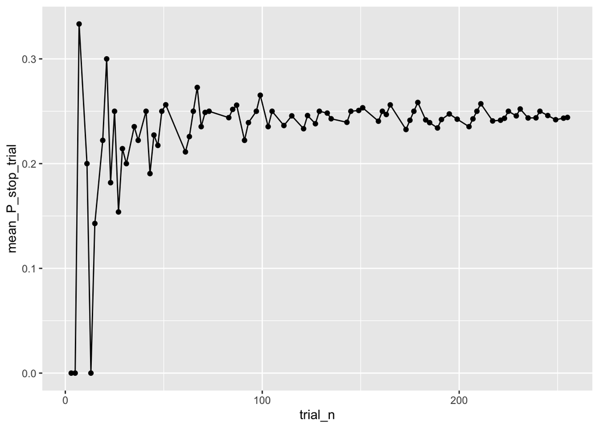

```r
P_stop_trial_over_trials<-FS_neural_behav_p %>% group_by(trial_n) %>% summarize(
  mean_P_stop_trial=mean(P_stop_trial,na.rm=TRUE),
  sd_P_stop_trial=sd(P_stop_trial,na.rm=TRUE))

ggplot(P_stop_trial_over_trials,aes(x=trial_n,y=mean_P_stop_trial))+geom_line()+geom_point()
```

We should examine whether this is anything but subjects getting used to the task at the start. What if we cut off the first 25 trials (i.e. trial_n=50; the count includes cues)?

```r
model_full_effects <- lme4::lmer(
   peak ~ trial_n_n +post_pre_rt_change + P_stop_trial_post +(1+ post_pre_rt_change | subid),
  FS_neural_behav_p %>% filter(trial_n>50)
  )
summary(model_full_effects)
```

```
## Linear mixed model fit by REML ['lmerMod']
## Formula: peak ~ trial_n_n + post_pre_rt_change + P_stop_trial_post + (1 +
##     post_pre_rt_change | subid)
##    Data: FS_neural_behav_p %>% filter(trial_n > 50)
##
## REML criterion at convergence: 4041.5
##
## Scaled residuals:
##     Min      1Q  Median      3Q     Max
## -5.7294 -0.6387  0.0164  0.6145  3.9115
##
## Random effects:
##  Groups   Name               Variance Std.Dev. Corr
##  subid    (Intercept)        0.004222 0.06497
##           post_pre_rt_change 0.050454 0.22462  -0.09
##  Residual                    0.192624 0.43889
## Number of obs: 3315, groups:  subid, 244
##
## Fixed effects:
##                    Estimate Std. Error t value
## (Intercept)         0.68796    0.19058   3.610
## trial_n_n           0.03354    0.01022   3.282
## post_pre_rt_change  0.15658    0.05421   2.888
## P_stop_trial_post  -1.65465    0.74074  -2.234
##
## Correlation of Fixed Effects:
##             (Intr) trl_n_ pst___
## trial_n_n    0.399
## pst_pr_rt_c  0.098  0.086
## P_stp_trl_p -0.999 -0.381 -0.112
```

Gosh that’s interesting–it still says significant. So this might say something worthwhile.

```r
model_full_effects <- lme4::lmer(
   peak ~ trial_n_n +post_pre_rt_change + P_stop_trial_post +(1+ post_pre_rt_change | subid),
  FS_neural_behav_p %>% filter(trial_n>50)
  )
summary(model_full_effects)
```

```
## Linear mixed model fit by REML ['lmerMod']
## Formula: peak ~ trial_n_n + post_pre_rt_change + P_stop_trial_post + (1 +
##     post_pre_rt_change | subid)
##    Data: FS_neural_behav_p %>% filter(trial_n > 50)
##
## REML criterion at convergence: 4041.5
##
## Scaled residuals:
##     Min      1Q  Median      3Q     Max
## -5.7294 -0.6387  0.0164  0.6145  3.9115
##
## Random effects:
##  Groups   Name               Variance Std.Dev. Corr
##  subid    (Intercept)        0.004222 0.06497
##           post_pre_rt_change 0.050454 0.22462  -0.09
##  Residual                    0.192624 0.43889
## Number of obs: 3315, groups:  subid, 244
##
## Fixed effects:
##                    Estimate Std. Error t value
## (Intercept)         0.68796    0.19058   3.610
## trial_n_n           0.03354    0.01022   3.282
## post_pre_rt_change  0.15658    0.05421   2.888
## P_stop_trial_post  -1.65465    0.74074  -2.234
##
## Correlation of Fixed Effects:
##             (Intr) trl_n_ pst___
## trial_n_n    0.399
## pst_pr_rt_c  0.098  0.086
## P_stp_trl_p -0.999 -0.381 -0.112
```

Let’s try it controlling for random effects…

```r
model_full_effects <- lme4::lmer(
   peak ~ trial_n_n +post_pre_rt_change + P_stop_trial_post +(1+ post_pre_rt_change+P_stop_trial_post | subid),
  FS_neural_behav_p %>% filter(trial_n>50)
  )
```

```
## boundary (singular) fit: see help('isSingular')
```

```r
summary(model_full_effects)
```

```
## Linear mixed model fit by REML ['lmerMod']
## Formula: peak ~ trial_n_n + post_pre_rt_change + P_stop_trial_post + (1 +
##     post_pre_rt_change + P_stop_trial_post | subid)
##    Data: FS_neural_behav_p %>% filter(trial_n > 50)
##
## REML criterion at convergence: 4041.7
##
## Scaled residuals:
##     Min      1Q  Median      3Q     Max
## -5.7345 -0.6384  0.0161  0.6141  3.9213
##
## Random effects:
##  Groups   Name               Variance Std.Dev. Corr
##  subid    (Intercept)        0.00000  0.0000
##           post_pre_rt_change 0.04851  0.2202     NaN
##           P_stop_trial_post  0.06421  0.2534     NaN -0.07
##  Residual                    0.19268  0.4390
## Number of obs: 3315, groups:  subid, 244
##
## Fixed effects:
##                    Estimate Std. Error t value
## (Intercept)         0.68726    0.19063   3.605
## trial_n_n           0.03351    0.01022   3.280
## post_pre_rt_change  0.15647    0.05412   2.891
## P_stop_trial_post  -1.65209    0.74145  -2.228
##
## Correlation of Fixed Effects:
##             (Intr) trl_n_ pst___
## trial_n_n    0.398
## pst_pr_rt_c  0.099  0.086
## P_stp_trl_p -0.999 -0.380 -0.114
## optimizer (nloptwrap) convergence code: 0 (OK)
## boundary (singular) fit: see help('isSingular')
```

```r
model_random_effects <- lme4::lmer(
   peak ~ trial_n_n +post_pre_rt_change  +(1+ post_pre_rt_change+P_stop_trial_post | subid),
  FS_neural_behav_p %>% filter(trial_n>50)
  )
```

```
## boundary (singular) fit: see help('isSingular')
```

```r
summary(model_random_effects)
```

```
## Linear mixed model fit by REML ['lmerMod']
## Formula: peak ~ trial_n_n + post_pre_rt_change + (1 + post_pre_rt_change +
##     P_stop_trial_post | subid)
##    Data: FS_neural_behav_p %>% filter(trial_n > 50)
##
## REML criterion at convergence: 4047.9
##
## Scaled residuals:
##     Min      1Q  Median      3Q     Max
## -5.7290 -0.6312  0.0097  0.6183  3.9317
##
## Random effects:
##  Groups   Name               Variance Std.Dev. Corr
##  subid    (Intercept)        0.00000  0.0000
##           post_pre_rt_change 0.04727  0.2174     NaN
##           P_stop_trial_post  0.06587  0.2567     NaN -0.09
##  Residual                    0.19289  0.4392
## Number of obs: 3315, groups:  subid, 244
##
## Fixed effects:
##                    Estimate Std. Error t value
## (Intercept)        0.263185   0.010230  25.726
## trial_n_n          0.024862   0.009457   2.629
## post_pre_rt_change 0.142663   0.053737   2.655
##
## Correlation of Fixed Effects:
##             (Intr) trl_n_
## trial_n_n    0.376
## pst_pr_rt_c -0.273  0.046
## optimizer (nloptwrap) convergence code: 0 (OK)
## boundary (singular) fit: see help('isSingular')
```

```r
anova(model_random_effects,model_full_effects)
```

```
## refitting model(s) with ML (instead of REML)
```

```
## Data: FS_neural_behav_p %>% filter(trial_n > 50)
## Models:
## model_random_effects: peak ~ trial_n_n + post_pre_rt_change + (1 + post_pre_rt_change + P_stop_trial_post | subid)
## model_full_effects: peak ~ trial_n_n + post_pre_rt_change + P_stop_trial_post + (1 + post_pre_rt_change + P_stop_trial_post | subid)
##                      npar    AIC    BIC  logLik deviance  Chisq Df Pr(>Chisq)
## model_random_effects   10 4048.8 4109.8 -2014.4   4028.8
## model_full_effects     11 4045.8 4113.0 -2011.9   4023.8 4.9636  1    0.02589 *
## ---
## Signif. codes:  0 '***' 0.001 '**' 0.01 '*' 0.05 '.' 0.1 ' ' 1
```

It seems to capture meaningful variance!

### Quadratic

```r
model_full_effects <- lme4::lmer(
   peak ~ trial_n_n +post_pre_rt_change + P_stop_trial_post+I(P_stop_trial_post^2) +(1+ post_pre_rt_change+P_stop_trial | subid),
  FS_neural_behav_p %>% filter(trial_n>50)
  )
```

```
## boundary (singular) fit: see help('isSingular')
```

```r
summary(model_full_effects)
```

```
## Linear mixed model fit by REML ['lmerMod']
## Formula:
## peak ~ trial_n_n + post_pre_rt_change + P_stop_trial_post + I(P_stop_trial_post^2) +
##     (1 + post_pre_rt_change + P_stop_trial | subid)
##    Data: FS_neural_behav_p %>% filter(trial_n > 50)
##
## REML criterion at convergence: 4028.6
##
## Scaled residuals:
##     Min      1Q  Median      3Q     Max
## -5.7517 -0.6255  0.0186  0.6159  3.8848
##
## Random effects:
##  Groups   Name               Variance Std.Dev. Corr
##  subid    (Intercept)         0.67354 0.8207
##           post_pre_rt_change  0.05384 0.2320   -0.77
##           P_stop_trial       10.16249 3.1879   -1.00  0.80
##  Residual                     0.19124 0.4373
## Number of obs: 3315, groups:  subid, 244
##
## Fixed effects:
##                        Estimate Std. Error t value
## (Intercept)             0.29313    1.85219   0.158
## trial_n_n               0.03390    0.01066   3.179
## post_pre_rt_change      0.15901    0.05419   2.934
## P_stop_trial_post       1.36500   14.18029   0.096
## I(P_stop_trial_post^2) -5.76565   27.14451  -0.212
##
## Correlation of Fixed Effects:
##             (Intr) trl_n_ pst___ P_st__
## trial_n_n   -0.178
## pst_pr_rt_c  0.024  0.043
## P_stp_trl_p -0.999  0.203 -0.024
## I(P_st__^2)  0.994 -0.225  0.022 -0.998
## optimizer (nloptwrap) convergence code: 0 (OK)
## boundary (singular) fit: see help('isSingular')
```

Nothing for the quadratic, though. What about just for the last trial only? I believe I already notcied an effect there in earlier work.

```r
model_full_effects <- lme4::lmer(
   peak ~ trial_n_n +post_pre_rt_change + P_stop_trial_post+(trials_since_last_SSD==1) +(1+ post_pre_rt_change+P_stop_trial_post | subid),
  FS_neural_behav_p %>% filter(trial_n>50)
  )
```

```
## boundary (singular) fit: see help('isSingular')
```

```r
summary(model_full_effects)
```

```
## Linear mixed model fit by REML ['lmerMod']
## Formula:
## peak ~ trial_n_n + post_pre_rt_change + P_stop_trial_post + (trials_since_last_SSD ==
##     1) + (1 + post_pre_rt_change + P_stop_trial_post | subid)
##    Data: FS_neural_behav_p %>% filter(trial_n > 50)
##
## REML criterion at convergence: 4047.5
##
## Scaled residuals:
##     Min      1Q  Median      3Q     Max
## -5.7234 -0.6339  0.0168  0.6132  3.9190
##
## Random effects:
##  Groups   Name               Variance Std.Dev. Corr
##  subid    (Intercept)        0.00000  0.0000
##           post_pre_rt_change 0.04901  0.2214     NaN
##           P_stop_trial_post  0.06381  0.2526     NaN -0.07
##  Residual                    0.19274  0.4390
## Number of obs: 3315, groups:  subid, 244
##
## Fixed effects:
##                                 Estimate Std. Error t value
## (Intercept)                     0.665927   0.208378   3.196
## trial_n_n                       0.033516   0.010218   3.280
## post_pre_rt_change              0.157838   0.054407   2.901
## P_stop_trial_post              -1.564526   0.817956  -1.913
## trials_since_last_SSD == 1TRUE -0.005448   0.021395  -0.255
##
## Correlation of Fixed Effects:
##             (Intr) trl_n_ pst___ P_st__
## trial_n_n    0.365
## pst_pr_rt_c  0.051  0.085
## P_stp_trl_p -0.999 -0.345 -0.062
## t___SSD==1T  0.403  0.002 -0.096 -0.422
## optimizer (nloptwrap) convergence code: 0 (OK)
## boundary (singular) fit: see help('isSingular')
```

```r
model_full_effects <- lme4::lmer(
   peak ~ trial_n_n +post_pre_rt_change + P_stop_trial+(trials_since_last_SSD==1) +(1+ post_pre_rt_change+P_stop_trial | subid),
  FS_neural_behav_p %>% filter(trial_n>50)
  )
```

```
## boundary (singular) fit: see help('isSingular')
```

```r
summary(model_full_effects)
```

```
## Linear mixed model fit by REML ['lmerMod']
## Formula:
## peak ~ trial_n_n + post_pre_rt_change + P_stop_trial + (trials_since_last_SSD ==
##     1) + (1 + post_pre_rt_change + P_stop_trial | subid)
##    Data: FS_neural_behav_p %>% filter(trial_n > 50)
##
## REML criterion at convergence: 4040.5
##
## Scaled residuals:
##     Min      1Q  Median      3Q     Max
## -5.7536 -0.6312  0.0188  0.6210  3.8864
##
## Random effects:
##  Groups   Name               Variance Std.Dev. Corr
##  subid    (Intercept)         0.67695 0.8228
##           post_pre_rt_change  0.05372 0.2318   -0.78
##           P_stop_trial       10.25198 3.2019   -1.00  0.81
##  Residual                     0.19115 0.4372
## Number of obs: 3315, groups:  subid, 244
##
## Fixed effects:
##                                 Estimate Std. Error t value
## (Intercept)                     0.736763   0.200394   3.677
## trial_n_n                       0.022650   0.009730   2.328
## post_pre_rt_change              0.160104   0.054392   2.944
## P_stop_trial                   -1.951416   0.828314  -2.356
## trials_since_last_SSD == 1TRUE -0.003083   0.021107  -0.146
##
## Correlation of Fixed Effects:
##             (Intr) trl_n_ pst___ P_stp_
## trial_n_n   -0.139
## pst_pr_rt_c -0.026  0.056
## P_stop_tril -0.998  0.162  0.015
## t___SSD==1T  0.372 -0.223 -0.095 -0.394
## optimizer (nloptwrap) convergence code: 0 (OK)
## boundary (singular) fit: see help('isSingular')
```

### Chagne in P_stop_trial

There is probably *change* in P_stop_trial to consider, too.

First we need to calculate it in the dataset.

```r
model_P_stop_trial_post <- lme4::lmer(
   peak ~ trial_n_n +post_pre_rt_change + P_stop_trial_post +(1+ post_pre_rt_change+P_stop_trial_post | subid),
  FS_neural_behav_p %>% filter(trial_n>50)
  )
```

```
## boundary (singular) fit: see help('isSingular')
```

```r
summary(model_P_stop_trial_post)
```

```
## Linear mixed model fit by REML ['lmerMod']
## Formula: peak ~ trial_n_n + post_pre_rt_change + P_stop_trial_post + (1 +
##     post_pre_rt_change + P_stop_trial_post | subid)
##    Data: FS_neural_behav_p %>% filter(trial_n > 50)
##
## REML criterion at convergence: 4041.7
##
## Scaled residuals:
##     Min      1Q  Median      3Q     Max
## -5.7345 -0.6384  0.0161  0.6141  3.9213
##
## Random effects:
##  Groups   Name               Variance Std.Dev. Corr
##  subid    (Intercept)        0.00000  0.0000
##           post_pre_rt_change 0.04851  0.2202     NaN
##           P_stop_trial_post  0.06421  0.2534     NaN -0.07
##  Residual                    0.19268  0.4390
## Number of obs: 3315, groups:  subid, 244
##
## Fixed effects:
##                    Estimate Std. Error t value
## (Intercept)         0.68726    0.19063   3.605
## trial_n_n           0.03351    0.01022   3.280
## post_pre_rt_change  0.15647    0.05412   2.891
## P_stop_trial_post  -1.65209    0.74145  -2.228
##
## Correlation of Fixed Effects:
##             (Intr) trl_n_ pst___
## trial_n_n    0.398
## pst_pr_rt_c  0.099  0.086
## P_stp_trl_p -0.999 -0.380 -0.114
## optimizer (nloptwrap) convergence code: 0 (OK)
## boundary (singular) fit: see help('isSingular')
```

```r
model_P_stop_trial_w_change <- lme4::lmer(
   peak ~ trial_n_n +post_pre_rt_change + P_stop_trial_post + P_stop_trial_change +(1+ post_pre_rt_change+P_stop_trial_post + P_stop_trial_change | subid),
  FS_neural_behav_p %>% filter(trial_n>50)
  )
```

```
## boundary (singular) fit: see help('isSingular')
```

```r
summary(model_P_stop_trial_w_change)
```

```
## Linear mixed model fit by REML ['lmerMod']
## Formula:
## peak ~ trial_n_n + post_pre_rt_change + P_stop_trial_post + P_stop_trial_change +
##     (1 + post_pre_rt_change + P_stop_trial_post + P_stop_trial_change |
##         subid)
##    Data: FS_neural_behav_p %>% filter(trial_n > 50)
##
## REML criterion at convergence: 4020.7
##
## Scaled residuals:
##     Min      1Q  Median      3Q     Max
## -5.8258 -0.6271  0.0164  0.6226  3.9427
##
## Random effects:
##  Groups   Name                Variance Std.Dev. Corr
##  subid    (Intercept)          0.38413 0.6198
##           post_pre_rt_change   0.05833 0.2415   -1.00
##           P_stop_trial_post    6.65403 2.5795   -0.99  0.99
##           P_stop_trial_change 94.60052 9.7263    0.46 -0.46 -0.55
##  Residual                      0.18873 0.4344
## Number of obs: 3315, groups:  subid, 244
##
## Fixed effects:
##                     Estimate Std. Error t value
## (Intercept)          0.54866    0.20534   2.672
## trial_n_n           -0.01538    0.02315  -0.664
## post_pre_rt_change   0.14948    0.05438   2.749
## P_stop_trial_post   -1.53331    0.77777  -1.971
## P_stop_trial_change  7.52006    3.27213   2.298
##
## Correlation of Fixed Effects:
##             (Intr) trl_n_ pst___ P_stp_trl_p
## trial_n_n    0.387
## pst_pr_rt_c  0.027  0.042
## P_stp_trl_p -0.973 -0.184 -0.036
## P_stp_trl_c -0.212 -0.874 -0.036 -0.012
## optimizer (nloptwrap) convergence code: 0 (OK)
## boundary (singular) fit: see help('isSingular')
```

So, if we include the *change* in probability of stop trial, that post isn’t quite significant anymore.

### Conclusion, Stop trial

Including that recent SSD thing does weaken the effect below significance.

# Individual subject learning rate

Can we estimate a subject “learning rate”? That would determine how much a subject changes their (1) response time and (2) post-pre RT change. The simplest way is to just, at a subject level, model change in RT as function of the gap. I’m not sure that’s quite going to work because probably subjects generally fully update each time.

First–can we predict the change as a function of P_stop and the peak?

```r
FS_neural_behav_p$post_pre_rt_change_z<-scale(FS_neural_behav_p$post_pre_rt_change)
FS_neural_behav_p$P_stop_trial_z<-scale(FS_neural_behav_p$P_stop_trial)
FS_neural_behav_p$peak_z<-scale(FS_neural_behav_p$peak)

model_full_effects <- lme4::lmer(
   post_pre_rt_change_z ~ trial_n_n + P_stop_trial_z +peak_z+ (1+ peak_z+P_stop_trial_z | subid),
  FS_neural_behav_p %>% filter(trial_n>50)
  )
```

```
## boundary (singular) fit: see help('isSingular')
```

```r
summary(model_full_effects)
```

```
## Linear mixed model fit by REML ['lmerMod']
## Formula: post_pre_rt_change_z ~ trial_n_n + P_stop_trial_z + peak_z +
##     (1 + peak_z + P_stop_trial_z | subid)
##    Data: FS_neural_behav_p %>% filter(trial_n > 50)
##
## REML criterion at convergence: 9236.8
##
## Scaled residuals:
##     Min      1Q  Median      3Q     Max
## -4.2266 -0.5625 -0.0331  0.5357  3.9078
##
## Random effects:
##  Groups   Name           Variance Std.Dev. Corr
##  subid    (Intercept)    0.011442 0.1070
##           peak_z         0.002314 0.0481   1.00
##           P_stop_trial_z 0.208975 0.4571   0.11 0.11
##  Residual                0.909440 0.9536
## Number of obs: 3315, groups:  subid, 244
##
## Fixed effects:
##                Estimate Std. Error t value
## (Intercept)    -0.14266    0.03291  -4.335
## trial_n_n      -0.04902    0.02076  -2.361
## P_stop_trial_z  0.61103    0.09078   6.731
## peak_z          0.05668    0.01789   3.168
##
## Correlation of Fixed Effects:
##             (Intr) trl_n_ P_st__
## trial_n_n    0.171
## P_stp_trl_z -0.728  0.109
## peak_z       0.010 -0.036  0.041
## optimizer (nloptwrap) convergence code: 0 (OK)
## boundary (singular) fit: see help('isSingular')
```

That’s very compelling!

If the two parameters are correlated, perhaps that represents a sort of learning rate?

```r
random_effects = ranef(model_full_effects)$subid

cor.test(random_effects$peak_z,random_effects$P_stop_trial_z)
```

```
##
##  Pearson's product-moment correlation
##
## data:  random_effects$peak_z and random_effects$P_stop_trial_z
## t = 18.688, df = 242, p-value < 2.2e-16
## alternative hypothesis: true correlation is not equal to 0
## 95 percent confidence interval:
##  0.7116692 0.8154429
## sample estimates:
##       cor
## 0.7685642
```

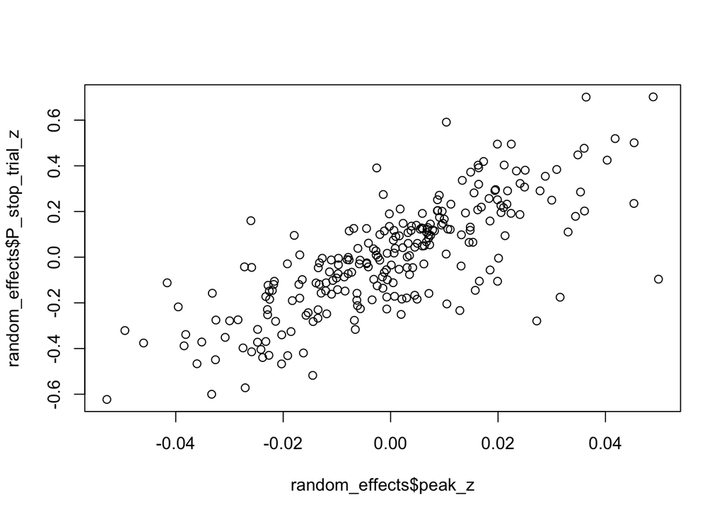

```r
plot(random_effects$peak_z,random_effects$P_stop_trial_z)
```

That’s probably more than just a learning rate, that’s some kind of banal statistical connection. Still, perhaps learning rate is in there? Could be if we can identify an individual feature.

```r
library(lattice)
#ranef(model_full_effects)
str(rr1 <- ranef(model_full_effects))
```

```
## List of 1
##  $ subid:'data.frame':   244 obs. of  3 variables:
##   ..$ (Intercept)   : num [1:244] -0.0283 -0.014 0.0249 0.0193 -0.0502 ...
##   ..$ peak_z        : num [1:244] -0.01272 -0.00629 0.01122 0.0087 -0.02258 ...
##   ..$ P_stop_trial_z: num [1:244] -0.00474 -0.1885 0.23184 0.20311 -0.14815 ...
##   ..- attr(*, "postVar")= num [1:3, 1:3, 1:244] 0.01033 0.00465 -0.00124 0.00465 0.00209 ...
##  - attr(*, "class")= chr "ranef.mer"
```

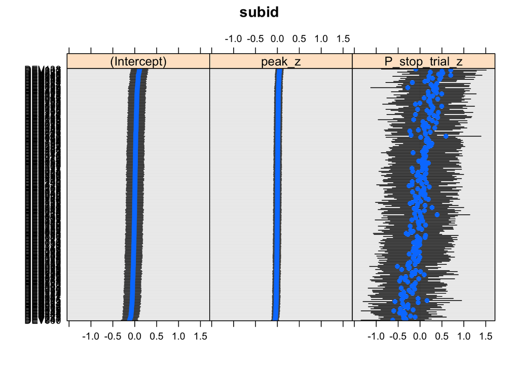

```r
dotplot(rr1)  ## default
```

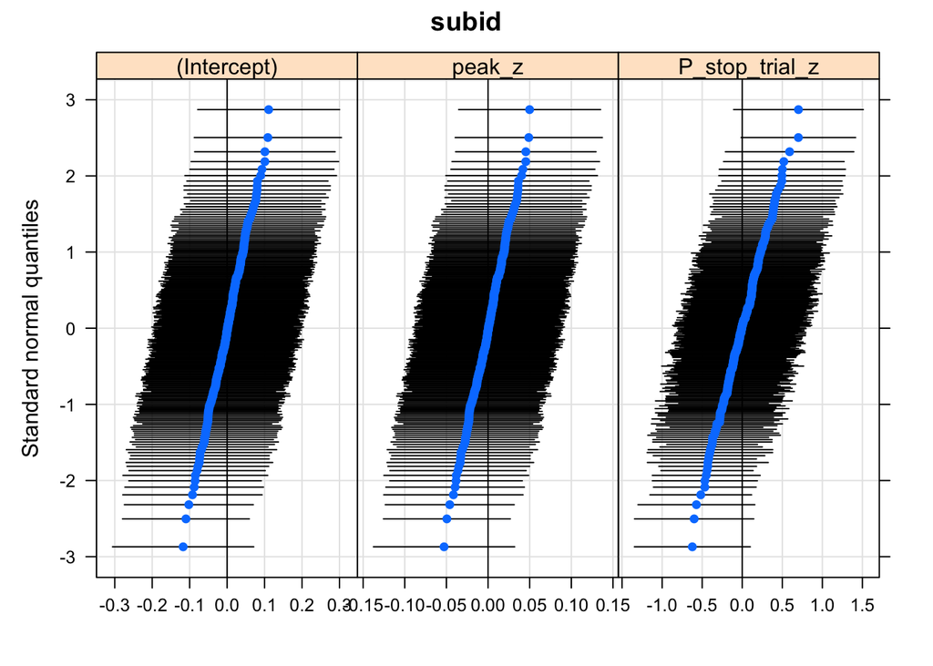

```r
qqmath(rr1)
```

```r
## specify free scales in order to make Day effects more visible
dotplot(rr1,scales = list(x = list(relation = 'free')))[["sub_id"]]
```

```r
## as.data.frame() provides RE's and conditional standard deviations:
str(dd <- as.data.frame(rr1))
```

```
## 'data.frame':    732 obs. of  5 variables:
##  $ grpvar : chr  "subid" "subid" "subid" "subid" ...
##  $ term   : Factor w/ 3 levels "(Intercept)",..: 1 1 1 1 1 1 1 1 1 1 ...
##  $ grp    : Factor w/ 244 levels "DEV060","DEV247",..: 62 86 183 169 33 51 205 20 53 192 ...
##  $ condval: num  -0.0283 -0.014 0.0249 0.0193 -0.0502 ...
##  $ condsd : num  0.1017 0.0904 0.1018 0.0989 0.0933 ...
```

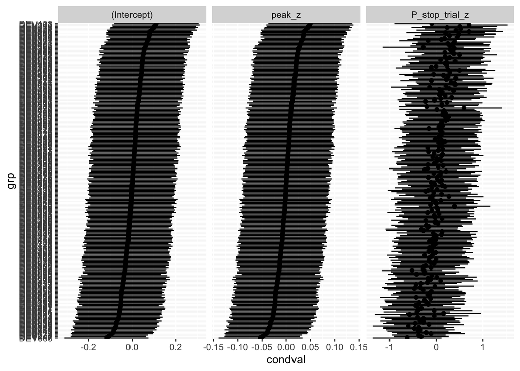

```r
if (require(ggplot2)) {
    ggplot(dd, aes(y=grp,x=condval)) +
        geom_point() + facet_wrap(~term,scales="free_x") +
        geom_errorbarh(aes(xmin=condval -2*condsd,
                           xmax=condval +2*condsd), height=0)
}
```

```r
data_by_ppt<- readr::read_csv(file = paste0("~/Dropbox (University of Oregon)/UO-SAN Lab/Berkman Lab/Devaluation/analysis_files/data/data_by_ppt.csv"))
```

OK, so we haven’t got anything here to measure learning, so I don’t think we do anything with these parameters…

```r
random_effects$subid<-rownames(random_effects)
data_by_ppt<-merge(data_by_ppt,random_effects,by.x = "SID",by.y="subid")

#cor.test(data_by_ppt$peak_z,data_by_ppt$BFI_extraversion)
cor.test(data_by_ppt$BIS_11,data_by_ppt$peak_z)
```

```
##
##  Pearson's product-moment correlation
##
## data:  data_by_ppt$BIS_11 and data_by_ppt$peak_z
## t = -0.13941, df = 228, p-value = 0.8892
## alternative hypothesis: true correlation is not equal to 0
## 95 percent confidence interval:
##  -0.1384256  0.1202697
## sample estimates:
##          cor
## -0.009232406
```

```r
cor.test(data_by_ppt$RTFS_f1_minus_f2,data_by_ppt$peak_z)
```

```
##
##  Pearson's product-moment correlation
##
## data:  data_by_ppt$RTFS_f1_minus_f2 and data_by_ppt$peak_z
## t = 0.20765, df = 168, p-value = 0.8358
## alternative hypothesis: true correlation is not equal to 0
## 95 percent confidence interval:
##  -0.1348207  0.1661323
## sample estimates:
##        cor
## 0.01601857
```

So what else can we do with this?

We wanted to know if the RT or the peak (not the peak regressor as above) related to RTFS or BIS_11

```r
fs_by_ppt<-merge(data_by_ppt, FS_by_subj_i,data,by.x = "SID",by.y="subid")

cor.test(fs_by_ppt$mean_post_pre_rt_change,fs_by_ppt$RTFS_f1_minus_f2)
```

```
##
##  Pearson's product-moment correlation
##
## data:  fs_by_ppt$mean_post_pre_rt_change and fs_by_ppt$RTFS_f1_minus_f2
## t = 0.22846, df = 168, p-value = 0.8196
## alternative hypothesis: true correlation is not equal to 0
## 95 percent confidence interval:
##  -0.1332445  0.1676927
## sample estimates:
##        cor
## 0.01762323
```

```r
cor.test(fs_by_ppt$mean_peak, fs_by_ppt$RTFS_f1_minus_f2)
```

```
##
##  Pearson's product-moment correlation
##
## data:  fs_by_ppt$mean_peak and fs_by_ppt$RTFS_f1_minus_f2
## t = -1.9146, df = 168, p-value = 0.05724
## alternative hypothesis: true correlation is not equal to 0
## 95 percent confidence interval:
##  -0.290259638  0.004483337
## sample estimates:
##        cor
## -0.1461295
```

```r
cor.test(fs_by_ppt$mean_peak, fs_by_ppt$RTFS_f1_minus_f2,method="spearman")
```

```
##
##  Spearman's rank correlation rho
##
## data:  fs_by_ppt$mean_peak and fs_by_ppt$RTFS_f1_minus_f2
## S = 949415, p-value = 0.03773
## alternative hypothesis: true rho is not equal to 0
## sample estimates:
##        rho
## -0.1595125
```

```r
cor.test(fs_by_ppt$mean_trough, fs_by_ppt$RTFS_f1_minus_f2,method="spearman")
```

```
##
##  Spearman's rank correlation rho
##
## data:  fs_by_ppt$mean_trough and fs_by_ppt$RTFS_f1_minus_f2
## S = 945666, p-value = 0.04366
## alternative hypothesis: true rho is not equal to 0
## sample estimates:
##        rho
## -0.1549338
```

```r
cor.test(fs_by_ppt$mean_amplitude, fs_by_ppt$RTFS_f1_minus_f2,method="spearman")
```

```
##
##  Spearman's rank correlation rho
##
## data:  fs_by_ppt$mean_amplitude and fs_by_ppt$RTFS_f1_minus_f2
## S = 796277, p-value = 0.7217
## alternative hypothesis: true rho is not equal to 0
## sample estimates:
##        rho
## 0.02751382
```

```r
cor.test(fs_by_ppt$mean_peak, fs_by_ppt$BIS_11,method="spearman")
```

```
##
##  Spearman's rank correlation rho
##
## data:  fs_by_ppt$mean_peak and fs_by_ppt$BIS_11
## S = 1910465, p-value = 0.3824
## alternative hypothesis: true rho is not equal to 0
## sample estimates:
##        rho
## 0.05786084
```

This validates that both $P(is stop)$ and the signal time are parameters to learn which striatal activity moderates in both of them.

If striatum responds to both, its activations should be a function of each of them, which we have observed within FS. However, we should also see this affect across all trials, not necessarily moderated by FS, but if FS did moderate it, that might be because striatal activity facilitates learning or updating amongst other parts of the brain. we might expect to see heightened striatal connectivity with other regions during those FS periods–though that’s an odd thing to say because the interesting thing is *decreased* connectivity during the periods of strong updating!

# All trial types, with P_Stop

```r
model_full_effects <- lme4::lmer(
   peak ~ trial_n_s+ condition + P_stop_trial_change+ post_pre_rt_change + post_pre_rt_change:(condition=="FailedStop")+ (1 +post_pre_rt_change + post_pre_rt_change:(condition=="FailedStop") + P_stop_trial_change  | subid),
  trial_neural_behav_roi %>% filter(trial_n>50)
  )
summary(model_full_effects)
```

```
## Linear mixed model fit by REML ['lmerMod']
## Formula:
## peak ~ trial_n_s + condition + P_stop_trial_change + post_pre_rt_change +
##     post_pre_rt_change:(condition == "FailedStop") + (1 + post_pre_rt_change +
##     post_pre_rt_change:(condition == "FailedStop") + P_stop_trial_change |
##     subid)
##    Data: trial_neural_behav_roi %>% filter(trial_n > 50)
##
## REML criterion at convergence: 35629.3
##
## Scaled residuals:
##      Min       1Q   Median       3Q      Max
## -13.3934  -0.6146   0.0043   0.6315   6.8738
##
## Random effects:
##  Groups   Name                                             Variance  Std.Dev.
##  subid    (Intercept)                                      0.0001977 0.01406
##           post_pre_rt_change                               0.0097720 0.09885
##           P_stop_trial_change                              8.4927268 2.91423
##           post_pre_rt_change:condition == "FailedStop"TRUE 0.1465637 0.38284
##  Residual                                                  0.1736287 0.41669
##  Corr
##
##  -0.23
##  -0.58  0.92
##   0.28 -0.52 -0.49
##
## Number of obs: 32570, groups:  subid, 244
##
## Fixed effects:
##                                                   Estimate Std. Error t value
## (Intercept)                                       0.181964   0.004281  42.501
## trial_n_s                                         0.014771   0.002921   5.056
## conditionCorrectStop                             -0.008353   0.013764  -0.607
## conditionFailedGo                                 0.043933   0.016838   2.609
## conditionFailedStop                               0.062831   0.014259   4.407
## P_stop_trial_change                               0.984591   0.761592   1.293
## post_pre_rt_change                                0.068613   0.018631   3.683
## post_pre_rt_change:condition == "FailedStop"TRUE  0.075645   0.058292   1.298
##
## Correlation of Fixed Effects:
##             (Intr) trl_n_ cndtCS cndtFG cndtFS P_st__ pst___
## trial_n_s    0.320
## cndtnCrrctS -0.715 -0.083
## conditnFldG -0.098  0.008  0.030
## cndtnFldStp -0.697 -0.083  0.713  0.031
## P_stp_trl_c  0.663  0.109 -0.807  0.001 -0.788
## pst_pr_rt_c  0.035  0.011 -0.037  0.037 -0.012  0.071
## p___:=="FS"  0.027  0.010 -0.004 -0.014 -0.175 -0.030 -0.358
## optimizer (nloptwrap) convergence code: 0 (OK)
## Model failed to converge with max|grad| = 0.015689 (tol = 0.002, component 1)
```

That interaction isn’t significant–let’s take it away

```r
model_full_effects <- lme4::lmer(
   peak ~ trial_n_s+ condition + +P_stop_trial_change+ post_pre_rt_change +  (1 +post_pre_rt_change +  P_stop_trial_change   | subid),
  trial_neural_behav_roi %>% filter(trial_n>50)
  )
summary(model_full_effects)
```

```
## Linear mixed model fit by REML ['lmerMod']
## Formula:
## peak ~ trial_n_s + condition + +P_stop_trial_change + post_pre_rt_change +
##     (1 + post_pre_rt_change + P_stop_trial_change | subid)
##    Data: trial_neural_behav_roi %>% filter(trial_n > 50)
##
## REML criterion at convergence: 35637.5
##
## Scaled residuals:
##      Min       1Q   Median       3Q      Max
## -13.3840  -0.6151   0.0038   0.6309   6.8586
##
## Random effects:
##  Groups   Name                Variance  Std.Dev. Corr
##  subid    (Intercept)         0.0002325 0.01525
##           post_pre_rt_change  0.0079684 0.08927  -0.11
##           P_stop_trial_change 7.7477520 2.78348  -0.58  0.81
##  Residual                     0.1739266 0.41705
## Number of obs: 32570, groups:  subid, 244
##
## Fixed effects:
##                       Estimate Std. Error t value
## (Intercept)           0.181930   0.004296  42.348
## trial_n_s             0.014654   0.002921   5.017
## conditionCorrectStop -0.007754   0.013754  -0.564
## conditionFailedGo     0.043854   0.016851   2.603
## conditionFailedStop   0.067483   0.013956   4.836
## P_stop_trial_change   0.920979   0.758333   1.214
## post_pre_rt_change    0.077825   0.017452   4.459
##
## Correlation of Fixed Effects:
##             (Intr) trl_n_ cndtCS cndtFG cndtFS P_st__
## trial_n_s    0.318
## cndtnCrrctS -0.712 -0.081
## conditnFldG -0.098  0.008  0.030
## cndtnFldStp -0.708 -0.080  0.727  0.029
## P_stp_trl_c  0.660  0.107 -0.809  0.001 -0.802
## pst_pr_rt_c  0.048  0.017 -0.043  0.036 -0.080  0.066
## optimizer (nloptwrap) convergence code: 0 (OK)
## Model failed to converge with max|grad| = 0.0540129 (tol = 0.002, component 1)
```

```r
model_full_effects <- lme4::lmer(
   peak ~ trial_n_s+ condition + +P_stop_trial_change+ post_pre_rt_change +  (1 +post_pre_rt_change +  P_stop_trial_change   | subid),
  trial_neural_behav_roi
  )
```

```
## boundary (singular) fit: see help('isSingular')
```

```r
summary(model_full_effects)
```

```
## Linear mixed model fit by REML ['lmerMod']
## Formula:
## peak ~ trial_n_s + condition + +P_stop_trial_change + post_pre_rt_change +
##     (1 + post_pre_rt_change + P_stop_trial_change | subid)
##    Data: trial_neural_behav_roi
##
## REML criterion at convergence: 46675.6
##
## Scaled residuals:
##      Min       1Q   Median       3Q      Max
## -13.1248  -0.6196   0.0069   0.6316   6.7605
##
## Random effects:
##  Groups   Name                Variance  Std.Dev. Corr
##  subid    (Intercept)         7.607e-06 0.002758
##           post_pre_rt_change  7.853e-03 0.088619 -1.00
##           P_stop_trial_change 8.193e-01 0.905145 -0.12  0.12
##  Residual                     1.805e-01 0.424846
## Number of obs: 41206, groups:  subid, 244
##
## Fixed effects:
##                       Estimate Std. Error t value
## (Intercept)          0.1677151  0.0024735  67.804
## trial_n_s            0.0002252  0.0021188   0.106
## conditionCorrectStop 0.0238236  0.0073171   3.256
## conditionFailedGo    0.0589176  0.0151406   3.891
## conditionFailedStop  0.0810931  0.0072313  11.214
## P_stop_trial_change  0.1003453  0.0826157   1.215
## post_pre_rt_change   0.0848662  0.0158656   5.349
##
## Correlation of Fixed Effects:
##             (Intr) trl_n_ cndtCS cndtFG cndtFS P_st__
## trial_n_s    0.024
## cndtnCrrctS -0.376  0.030
## conditnFldG -0.142  0.001  0.039
## cndtnFldStp -0.417 -0.055  0.207  0.034
## P_stp_trl_c  0.147  0.018 -0.176  0.031 -0.265
## pst_pr_rt_c  0.060  0.034 -0.061  0.045 -0.127  0.039
## optimizer (nloptwrap) convergence code: 0 (OK)
## boundary (singular) fit: see help('isSingular')
```

We’ve changed this code to use `P_stop_trial_change` ratehr than `P_stop_trial_post`. `P_stop_trial_change` makes more theoretical sense (since we’re trying to measure how much the striatal effect is an update) yet it isn’t a significant regressor.

```r
model_full_effects <- lme4::lmer(
   peak ~ trial_n_s+ condition + +P_stop_trial_change+P_stop_trial_post+ post_pre_rt_change +  (1 +post_pre_rt_change +  P_stop_trial_change +P_stop_trial_post  | subid),
  trial_neural_behav_roi %>% filter(trial_n>50)
  )
```

```
## boundary (singular) fit: see help('isSingular')
```

```r
summary(model_full_effects)
```

```
## Linear mixed model fit by REML ['lmerMod']
## Formula:
## peak ~ trial_n_s + condition + +P_stop_trial_change + P_stop_trial_post +
##     post_pre_rt_change + (1 + post_pre_rt_change + P_stop_trial_change +
##     P_stop_trial_post | subid)
##    Data: trial_neural_behav_roi %>% filter(trial_n > 50)
##
## REML criterion at convergence: 35571.9
##
## Scaled residuals:
##      Min       1Q   Median       3Q      Max
## -13.2977  -0.6159   0.0021   0.6306   6.8014
##
## Random effects:
##  Groups   Name                Variance  Std.Dev. Corr
##  subid    (Intercept)          0.520112 0.72119
##           post_pre_rt_change   0.009207 0.09595   0.59
##           P_stop_trial_change 10.305618 3.21024   0.50  0.88
##           P_stop_trial_post    8.395341 2.89747  -1.00 -0.59 -0.51
##  Residual                      0.172828 0.41573
## Number of obs: 32570, groups:  subid, 244
##
## Fixed effects:
##                       Estimate Std. Error t value
## (Intercept)           0.336126   0.070273   4.783
## trial_n_s             0.015833   0.002940   5.386
## conditionCorrectStop -0.006459   0.013746  -0.470
## conditionFailedGo     0.046066   0.016856   2.733
## conditionFailedStop   0.068619   0.013936   4.924
## P_stop_trial_change   1.162754   0.768045   1.514
## P_stop_trial_post    -0.615753   0.281097  -2.191
## post_pre_rt_change    0.080088   0.017570   4.558
##
## Correlation of Fixed Effects:
##             (Intr) trl_n_ cndtCS cndtFG cndtFS P_stp_trl_c P_stp_trl_p
## trial_n_s    0.110
## cndtnCrrctS -0.004 -0.073
## conditnFldG  0.024  0.011  0.032
## cndtnFldStp -0.024 -0.075  0.727  0.030
## P_stp_trl_c  0.202  0.115 -0.792  0.005 -0.788
## P_stp_trl_p -0.998 -0.091 -0.040 -0.030 -0.019 -0.162
## pst_pr_rt_c  0.162  0.020 -0.041  0.037 -0.078  0.089      -0.159
## optimizer (nloptwrap) convergence code: 0 (OK)
## boundary (singular) fit: see help('isSingular')
```